# Proyecto Final RNA-seq: Entregables 1–4

Análisis transcriptómico del modelo Dp(16)1Yey (Síndrome de Down)

Equipo 4 — Rubí Martínez Chavarría (rmartinez) & Leonardo Ivan Anaya Gonzalez (lanaya)

2026-05-25

# Entregable 1: Descripción del proyecto y selección de muestras

## Descripción del equipo

- **Equipo:** Equipo 4
- **Integrantes:**
  - Rubí Martínez Chavarría (rmartinez)
  - Leonardo Ivan Anaya Gonzalez (lanaya)
- **Correos electrónicos:** rubimarch201@gmail.com | leoianayaglz@gmail.com

## Descripción de los datos

Tabla 1. Descripción del bioproyecto GSE296420.

[output not shown]

El artículo *“Altered hepatic metabolism in Down syndrome”* (Dunn et al., 2026) analiza las consecuencias metabólicas de la trisomía 21 en el hígado usando un enfoque multi-ómico en más de 400 participantes del **Human Trisome Project**, junto con el modelo murino Dp(16)1Yey (Dp16). Este modelo porta una duplicación del segmento del cromosoma 16 murino homólogo al cromosoma 21 humano. El estudio reporta niveles elevados de ácidos biliares, inflamación hepática, fibrosis y una reacción ductular en los ratones Dp16.

## Muestras seleccionadas

Tabla 2. Muestras seleccionadas para el análisis.

[output not shown]

# Entregable 2: Control de calidad de datos crudos

## Descripción del equipo

- **Equipo:** Equipo 4
- **Integrantes:**
  - Rubí Martínez Chavarría (rmartinez)
  - Leonardo Ivan Anaya Gonzalez (lanaya)
- **Correos electrónicos:** rubimarch201@gmail.com | leoianayaglz@gmail.com

## Descripción del bioproyecto

Tabla 3. Detalles del Bioproyecto y características de las muestras.

[output not shown]

Para fines de esta práctica, se seleccionaron las muestras de tejido hepático de ratones adultos wild-type (WT) y Dp16, correspondientes al dataset GSE296420:

Tabla 4. Distribución de las muestras y réplicas biológicas.

| Muestra | GEO_Sample | Condicion | Genotipo | Tejido | Replica |
| --- | --- | --- | --- | --- | --- |
| Sample_WT_173_13422_Lv | GSM8970167 | WT | Wild-type C57BL/6J | Hígado | WT_1 |
| Sample_WT_179_13423_Lv | GSM8970168 | WT | Wild-type C57BL/6J | Hígado | WT_2 |
| Sample_WT_184_13425_Lv | GSM8970169 | WT | Wild-type C57BL/6J | Hígado | WT_3 |
| Sample_WT_186_13426_Lv | GSM8970170 | WT | Wild-type C57BL/6J | Hígado | WT_4 |
| Sample_WT_191_13428_Lv | GSM8970171 | WT | Wild-type C57BL/6J | Hígado | WT_5 |
| Sample_WT_196_13429_Lv | GSM8970172 | WT | Wild-type C57BL/6J | Hígado | WT_6 |
| Sample_Dp16_173_13422_Lv | GSM8970173 | Dp16 | Dp(16)1Yey | Hígado | Dp16_1 |
| Sample_Dp16_179_13423_Lv | GSM8970174 | Dp16 | Dp(16)1Yey | Hígado | Dp16_2 |
| Sample_Dp16_184_13425_Lv | GSM8970175 | Dp16 | Dp(16)1Yey | Hígado | Dp16_3 |
| Sample_Dp16_186_13426_Lv | GSM8970176 | Dp16 | Dp(16)1Yey | Hígado | Dp16_4 |
| Sample_Dp16_191_13428_Lv | GSM8970177 | Dp16 | Dp(16)1Yey | Hígado | Dp16_5 |
| Sample_Dp16_196_13429_Lv | GSM8970178 | Dp16 | Dp(16)1Yey | Hígado | Dp16_6 |

## Calidad de las secuencias de los datos crudos

Se analizó la calidad de las secuencias en los datos crudos mediante **FastQC** y la visualización conjunta con **MultiQC**, evaluando métricas como contenido de GC, profundidad de lectura, puntaje Phred y presencia de adaptadores.

### Calidad general de las lecturas

Las muestras presentan una calidad óptima, con valores dentro de la zona verde y un puntaje Phred superior a 30 en la mayoría de las posiciones. El promedio de calidad por base muestra un pico máximo cercano a Phred 35.

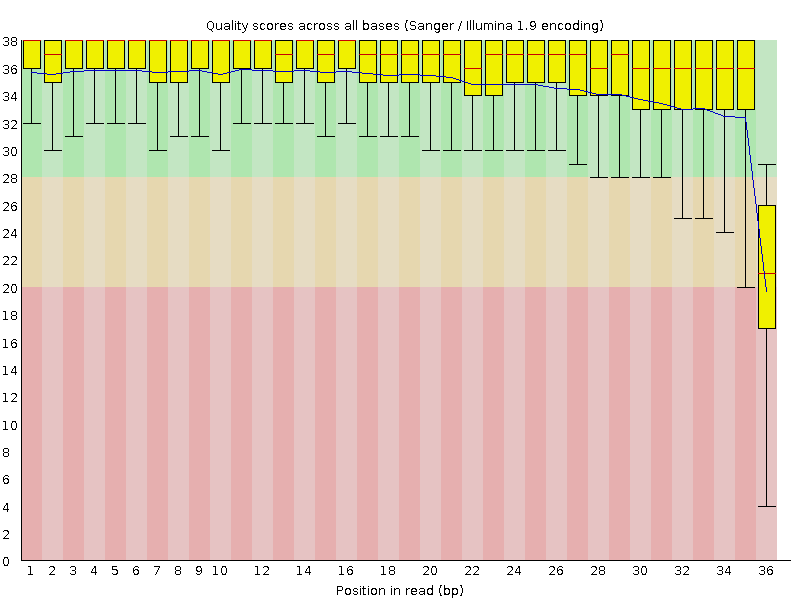

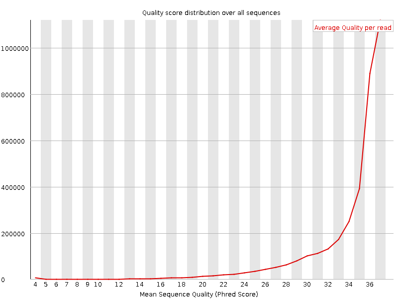

Figura 1. Calidad de las secuencias y por posición de base en las muestras WT y Dp16.

### Contenido de GC

Se identificaron variaciones en el porcentaje de %GC en algunas muestras, lo cual podría estar relacionado con contaminación o sesgo de amplificación.

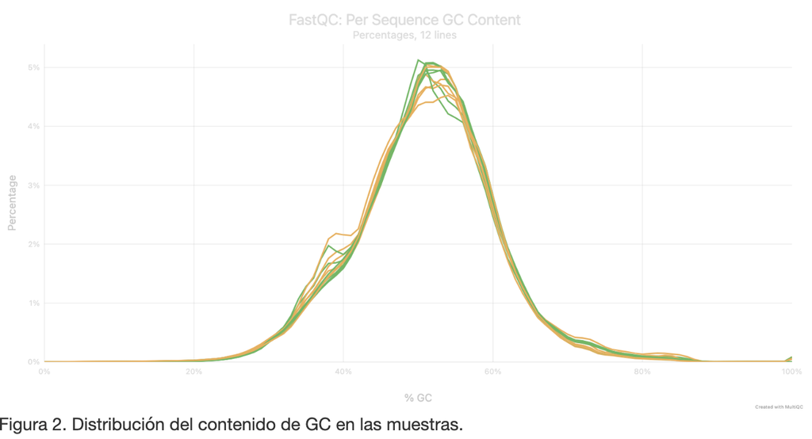

Figura 2. Distribución del contenido de GC en las muestras.

### Secuencias duplicadas

Se identificaron secuencias duplicadas en algunas muestras, posiblemente relacionadas con la presencia de dímeros de adaptadores o alta profundidad de secuenciación.

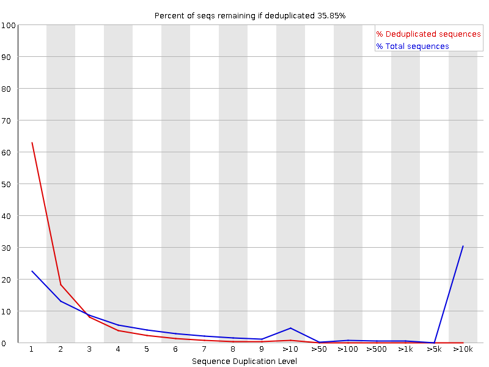

Figura 3. Calidad de las secuencias y niveles de duplicación.

Asimismo se identificaron también los adaptadores:

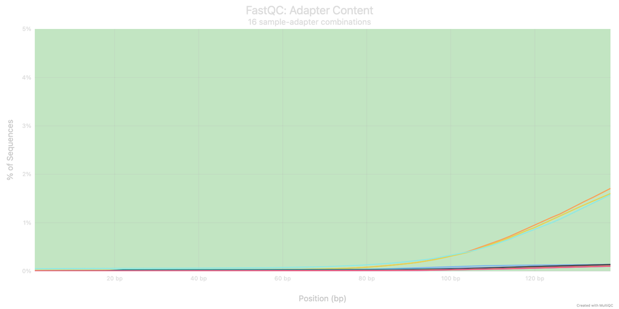

Figura 4. Adaptadores.

## Selección de muestras para el análisis

Con base en los resultados del análisis de calidad, se seleccionaron 6 muestras para el análisis diferencial: 3 controles (wild-type) y 3 tratamientos (Dp16). Para la selección se priorizaron muestras con mayor profundidad de secuenciación y menor porcentaje de duplicación.

Tabla 5. Muestras seleccionadas para el análisis diferencial.

[output not shown]

## Conclusión

Los resultados del análisis de calidad muestran que los datos son adecuados para continuar con el procesamiento y análisis posterior. Las secuencias presentan una buena calidad general, con valores de Phred superiores a 30 y un contenido de GC apropiado para tejido hepático murino (~50%). Aunque se observan algunas variaciones en el %GC y presencia de secuencias duplicadas, estas serán abordadas en la etapa de limpieza. Se procederá a eliminar adaptadores y secuencias de baja calidad con **Trimmomatic** antes de continuar con el alineamiento y cuantificación de expresión génica.

# Entregable 3: Eliminación de Adaptadores, Control de Calidad y Alineamiento

## Descripción del equipo

- **Equipo:** Equipo 4
- **Integrantes:**
  - Rubí Martínez Chavarría (rmartinez)
  - Leonardo Ivan Anaya Gonzalez (lanaya)
- **Correos electrónicos:** rubimarch201@gmail.com | leoianayaglz@gmail.com

## 1. Descripción de los datos

Tabla 6. Detalles del Bioproyecto GSE296420.

[output not shown]

Para esta práctica se seleccionaron 6 muestras de tejido hepático: 3 wild-type (WT) y 3 Dp16.

Tabla 7. Muestras seleccionadas para el análisis diferencial.

| SRR | Condicion | Genotipo | Tejido | Replica |
| --- | --- | --- | --- | --- |
| SRR33445252 | Control (WT) | Wild-type C57BL/6J | Hígado | WT_1 |
| SRR33445253 | Control (WT) | Wild-type C57BL/6J | Hígado | WT_2 |
| SRR33445254 | Control (WT) | Wild-type C57BL/6J | Hígado | WT_3 |
| SRR33445260 | Tratamiento (Dp16) | Dp(16)1Yey | Hígado | Dp16_1 |
| SRR33445261 | Tratamiento (Dp16) | Dp(16)1Yey | Hígado | Dp16_2 |
| SRR33445262 | Tratamiento (Dp16) | Dp(16)1Yey | Hígado | Dp16_3 |

## 2. Control de calidad de datos crudos (FastQC y MultiQC)

Se analizó la calidad de las secuencias en los datos crudos mediante **FastQC** y **MultiQC**, evaluando métricas como contenido de GC, profundidad de lectura, puntaje Phred y presencia de adaptadores.

Los resultados de FastQC/MultiQC se encuentran en el cluster en: `/mnt/data/bioinfo-estadistica-2/RNAseq_2026/equipos/Equipo4/quality1/`

### 2.1 Conteo de secuencias

Las 6 muestras presentan entre 43 y 51 millones de lecturas de entrada, lo cual representa una profundidad de secuenciación adecuada para el análisis de expresión diferencial en tejido hepático.

[figure not shown]

### 2.2 Calidad de las lecturas por posición de base

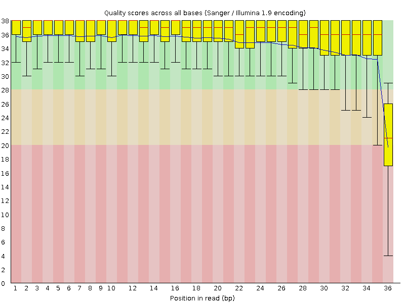

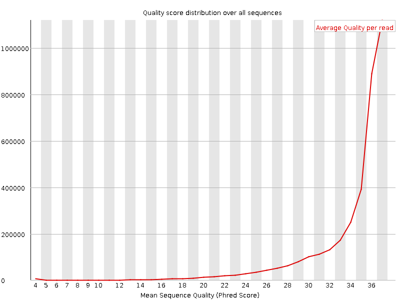

Figura 7. Distribución de puntajes de calidad por secuencia (datos crudos).

### 2.3 Niveles de duplicación

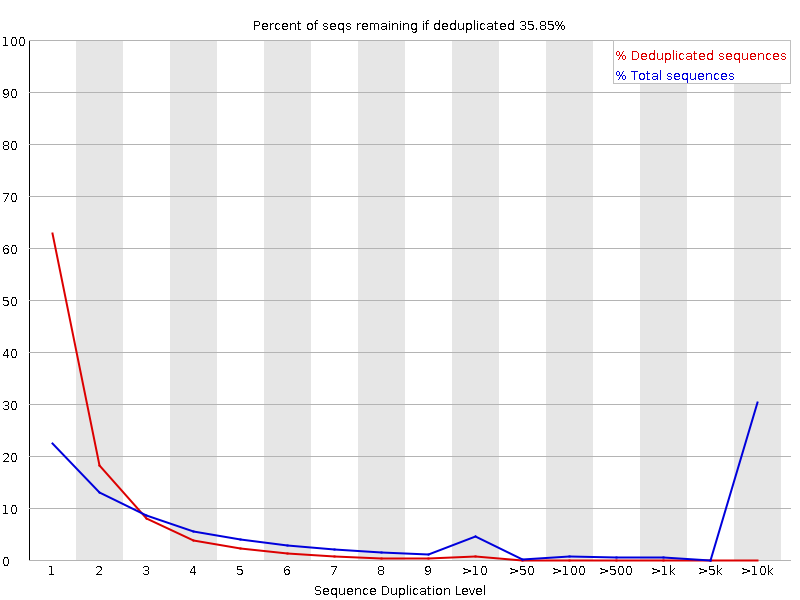

Figura 8. Niveles de duplicación de secuencias (datos crudos).

### 2.4 Contenido de adaptadores (datos crudos)

Se detectó la presencia de adaptadores **TruSeq3-PE** de Illumina en las muestras, con niveles que aumentan hacia el extremo 3’ de los reads — patrón esperado cuando los fragmentos son más cortos que el read.

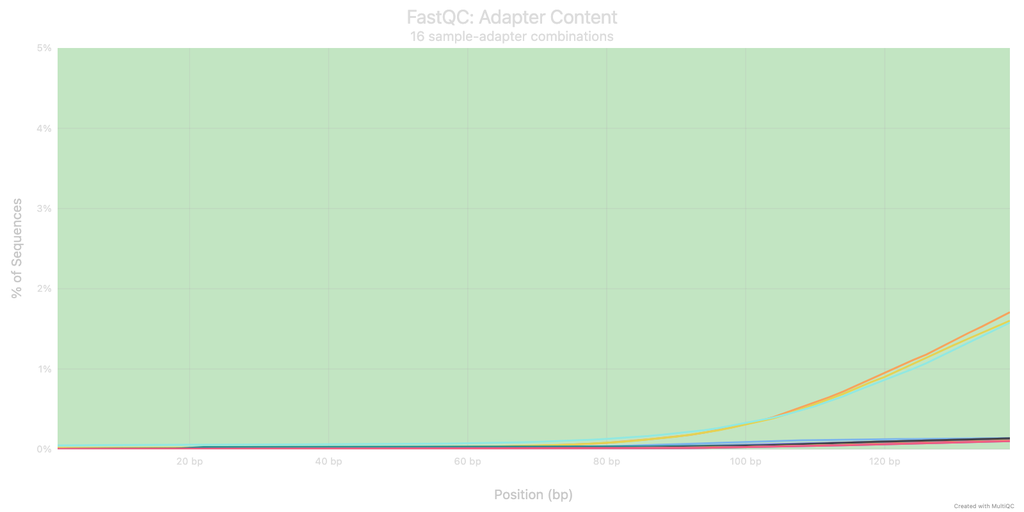

Figura 9. Contenido de adaptadores en los datos crudos.

### 2.5 Conclusión sobre los datos crudos

Los datos crudos presentan una **calidad general óptima**: Phred > 30 en prácticamente todas las posiciones, contenido de GC apropiado para tejido hepático murino (~50%), niveles de duplicación esperados para RNA-seq de alta profundidad, y **adaptadores TruSeq3-PE** que deben eliminarse antes del alineamiento.

**Pasos para mejorar la calidad:**

1. Eliminar los adaptadores TruSeq3-PE con Trimmomatic
2. Recortar bases de baja calidad (Phred < 20) con SLIDINGWINDOW
3. Eliminar bases de baja calidad al inicio (LEADING:5) y al final (TRAILING:5)
4. Descartar lecturas muy cortas después del trimming (MINLEN:36)
5. Verificar la calidad nuevamente con FastQC/MultiQC post-trimming

## 3. Eliminación de adaptadores con Trimmomatic

Las lecturas de RNA-seq pueden contener **adaptadores** al final que el alineador no puede mapear correctamente. Se utilizaron los adaptadores **TruSeq3-PE** (Paired-End), descargados del repositorio oficial de Trimmomatic y guardados en: `/mnt/data/bioinfo-estadistica-2/RNAseq_2026/equipos/Equipo4/adapters/TruSeq3-PE.fa`

### Script utilizado (SLURM job array)

```bash
#!/bin/bash
#SBATCH --job-name=trimmomatic_equipo4
#SBATCH --cpus-per-task=8
#SBATCH --mem=16G
#SBATCH --array=0-5

module load trimmomatic/0.33

trimmomatic PE \
    -threads 8 \
    -phred33 \
    ${SAMPLE}_1.fastq ${SAMPLE}_2.fastq \
    ${SAMPLE}_1_paired.fastq.gz   ${SAMPLE}_1_unpaired.fastq.gz \
    ${SAMPLE}_2_paired.fastq.gz   ${SAMPLE}_2_unpaired.fastq.gz \
    ILLUMINACLIP:TruSeq3-PE.fa:2:30:10 \
    LEADING:5 \
    TRAILING:5 \
    SLIDINGWINDOW:4:20 \
    MINLEN:36
```

**Explicación de parámetros:**

| Parámetro | Significado |
| --- | --- |
| `PE` | Modo paired-end |
| `-phred33` | Escala de calidad Phred+33, estándar en Illumina moderno |
| `ILLUMINACLIP:2:30:10` | Elimina adaptadores TruSeq3-PE con máximo 2 desajustes |
| `LEADING:5` | Elimina bases del inicio con calidad Phred < 5 |
| `TRAILING:5` | Elimina bases del final con calidad Phred < 5 |
| `SLIDINGWINDOW:4:20` | Recorre en ventanas de 4 bases y corta si el promedio cae bajo Phred 20 |
| `MINLEN:36` | Descarta lecturas menores a 36 bases después del recorte |

### Resultados del trimming

Tabla 8. Resultados del trimming con Trimmomatic.

| Muestra | Grupo | Reads entrada | Both surviving | Dropped |
| --- | --- | --- | --- | --- |
| SRR33445252 | Control (WT) | 45,264,999 | 25,617,073 (56.59%) | 2.50% |
| SRR33445253 | Control (WT) | 43,357,474 | 25,779,245 (59.46%) | 2.51% |
| SRR33445254 | Control (WT) | 48,399,669 | 29,207,061 (60.35%) | 2.65% |
| SRR33445260 | Tratamiento (Dp16) | 50,327,443 | 30,054,674 (59.72%) | 2.44% |
| SRR33445261 | Tratamiento (Dp16) | 50,277,394 | 30,669,829 (61.00%) | 2.31% |
| SRR33445262 | Tratamiento (Dp16) | 51,227,777 | 31,712,682 (61.91%) | 2.45% |

En todas las muestras se descartó menos del **3%** de las lecturas, lo que indica que los datos tenían buena calidad inicial y que el trimming fue exitoso.

### Control de calidad post-trimming

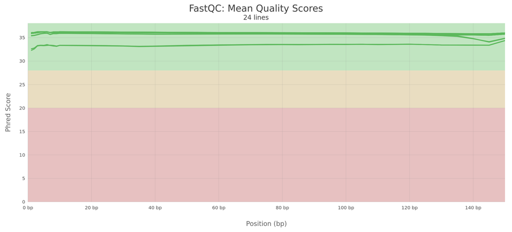

Figura 10. Calidad post-trimming por posición de base.

La calidad post-trimming se mantiene alta (Phred > 30) en todas las posiciones, y el contenido de adaptadores se redujo a cero.

## 4. Diagrama de flujo del pipeline

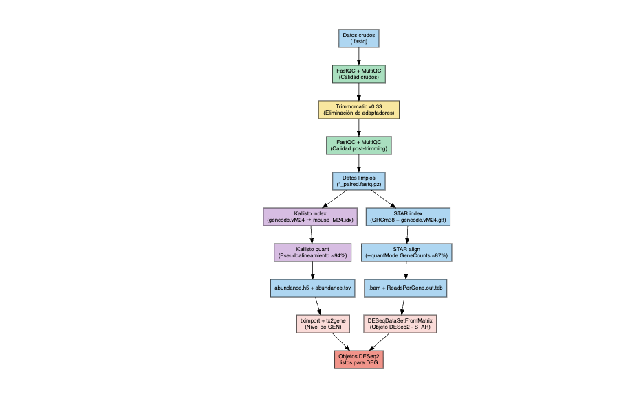

Figura 11. Diagrama de flujo del pipeline de análisis de RNA-seq.

## 5. Alineamiento y cuantificación

### 5.1 Pseudoalineamiento con Kallisto

Kallisto realiza un **pseudoalineamiento** usando k-mers (secuencias cortas de 31 bp) para determinar a qué transcrito pertenece cada lectura. Es extremadamente rápido y trabaja con el transcriptoma (Gencode vM24).

**Verificación del índice:**

```
[index] k-mer length: 31
[index] number of targets: 142,552
[index] number of k-mers: 120,672,054
[index] number of equivalence classes: 512,483
```

**Outlogs:** `/mnt/data/bioinfo-estadistica-2/RNAseq_2026/equipos/Equipo4/scripts/out_logs/kallisto_1511_*.out`

Tabla 9. Resultados del pseudoalineamiento con Kallisto.

| Muestra | Grupo | Reads procesados | Pseudoalineados | % |
| --- | --- | --- | --- | --- |
| SRR33445252 | Control (WT) | 25,617,073 | 24,186,844 | 94.4% |
| SRR33445253 | Control (WT) | 25,779,245 | 24,386,201 | 94.6% |
| SRR33445254 | Control (WT) | 29,207,061 | 27,917,712 | 95.6% |
| SRR33445260 | Tratamiento (Dp16) | 30,054,674 | 28,689,644 | 95.5% |
| SRR33445261 | Tratamiento (Dp16) | 30,669,829 | 29,200,606 | 95.2% |
| SRR33445262 | Tratamiento (Dp16) | 31,712,682 | 30,246,804 | 95.4% |

Un porcentaje superior al **94%** en todas las muestras indica excelente compatibilidad con la referencia Gencode vM24.

### 5.2 Alineamiento con STAR

STAR realiza un **alineamiento real** de cada lectura al genoma completo (GRCm38), detectando sitios de splicing. Genera archivos BAM con la posición exacta de cada lectura y cuenta lecturas por gen con `--quantMode GeneCounts`.

**Outlogs:** `/mnt/data/bioinfo-estadistica-2/RNAseq_2026/equipos/Equipo4/scripts/out_logs/STAR_align_1520_*.out`

**Resultados del alineamiento (muestra representativa SRR33445252):**

| Métrica | Valor |
| --- | --- |
| Reads de entrada | 25,617,073 |
| Uniquely mapped | 22,311,173 (**87.09%**) |
| Multi-mapping | 1,398,591 (5.46%) |
| Unmapped (too short) | 1,024,224 (4.00%) |
| Mismatch rate | 0.28% |

Un porcentaje de alineamiento único superior al **87%** es excelente para datos de RNA-seq de hígado de ratón.

## 6. Importación de datos en R

### 6.1 Datos de Kallisto con tximport (nivel de gen)

Kallisto genera estimaciones a nivel de **transcrito**. Para el análisis de expresión diferencial con DESeq2 necesitamos trabajar a nivel de **gen**. `tximport` con una tabla `tx2gene` agrupa los transcritos por gen, corrigiendo los sesgos por longitud de transcrito.

```r
library(tximport)
library(DESeq2)
library(rhdf5)

ruta <- "../results_final/kallisto"

samples <- c("SRR33445252","SRR33445253","SRR33445254",
             "SRR33445260","SRR33445261","SRR33445262")

archivos_h5 <- file.path(ruta, samples, "abundance.h5")
names(archivos_h5) <- samples
print(archivos_h5)
```

```
##                                          SRR33445252
## "../results_final/kallisto/SRR33445252/abundance.h5"
##                                          SRR33445253
## "../results_final/kallisto/SRR33445253/abundance.h5"
##                                          SRR33445254
## "../results_final/kallisto/SRR33445254/abundance.h5"
##                                          SRR33445260
## "../results_final/kallisto/SRR33445260/abundance.h5"
##                                          SRR33445261
## "../results_final/kallisto/SRR33445261/abundance.h5"
##                                          SRR33445262
## "../results_final/kallisto/SRR33445262/abundance.h5"
```

```r
tx2gene <- read.csv("../results_final/tx2gene_kallisto.csv")
head(tx2gene)
```

```
##                 TXNAME               GENEID
## 1 ENSMUST00000193812.1 ENSMUSG00000102693.1
## 2 ENSMUST00000082908.1 ENSMUSG00000064842.1
## 3 ENSMUST00000162897.1 ENSMUSG00000051951.5
## 4 ENSMUST00000159265.1 ENSMUSG00000051951.5
## 5 ENSMUST00000070533.4 ENSMUSG00000051951.5
## 6 ENSMUST00000192857.1 ENSMUSG00000102851.1
```

```r
cat("Total transcritos en tx2gene:", nrow(tx2gene), "\n")
```

```
## Total transcritos en tx2gene: 142552
```

```r
metadata <- read.csv("../metadata.csv")
metadata$genotype <- factor(metadata$genotype, levels = c("WT", "Dp16"))
rownames(metadata) <- metadata$sample
metadata
```

```
##                  sample genotype tissue
## SRR33445252 SRR33445252       WT  liver
## SRR33445253 SRR33445253       WT  liver
## SRR33445254 SRR33445254       WT  liver
## SRR33445260 SRR33445260     Dp16  liver
## SRR33445261 SRR33445261     Dp16  liver
## SRR33445262 SRR33445262     Dp16  liver
```

```r
txi.kallisto <- tximport(archivos_h5,
                         type = "kallisto",
                         tx2gene = tx2gene,
                         txOut = FALSE,
                         ignoreTxVersion = FALSE,
                         ignoreAfterBar = TRUE)
```

```
## 1 2 3 4 5 6
## summarizing abundance
## summarizing counts
## summarizing length
```

```r
cat("Genes:", nrow(txi.kallisto$counts), "\n")
```

```
## Genes: 55385
```

```r
cat("Muestras:", ncol(txi.kallisto$counts), "\n")
```

```
## Muestras: 6
```

```r
head(txi.kallisto$counts)
```

```
##                       SRR33445252 SRR33445253 SRR33445254 SRR33445260
## ENSMUSG00000000001.4         1402        1746        1925        2242
## ENSMUSG00000000003.15           0           0           0           0
## ENSMUSG00000000028.15          42          46          31          35
## ENSMUSG00000000031.16          33          28          91          96
## ENSMUSG00000000037.17           3           0           1           1
## ENSMUSG00000000049.11       35910       35216       48769       50417
##                       SRR33445261 SRR33445262
## ENSMUSG00000000001.4         2558        2162
## ENSMUSG00000000003.15           0           0
## ENSMUSG00000000028.15          42          23
## ENSMUSG00000000031.16           9           8
## ENSMUSG00000000037.17           1           0
## ENSMUSG00000000049.11       55995       55722
```

```r
dds <- DESeqDataSetFromTximport(txi.kallisto,
                                colData = metadata,
                                design = ~ genotype)
```

```
## using counts and average transcript lengths from tximport
```

```r
keep <- rowSums(counts(dds) >= 10) >= 3
dds <- dds[keep,]
cat("Genes después del filtrado:", nrow(dds), "\n")
```

```
## Genes después del filtrado: 14715
```

```r
dds
```

```
## class: DESeqDataSet
## dim: 14715 6
## metadata(1): version
## assays(2): counts avgTxLength
## rownames(14715): ENSMUSG00000000001.4 ENSMUSG00000000028.15 ...
##   ENSMUSG00000118631.1 ENSMUSG00000118633.1
## rowData names(0):
## colnames(6): SRR33445252 SRR33445253 ... SRR33445261 SRR33445262
## colData names(3): sample genotype tissue
```

### 6.2 Datos de STAR

```r
star_dir <- "../results_final/STAR"

count_list <- lapply(samples, function(s) {
    f <- file.path(star_dir, s, paste0(s, ".ReadsPerGene.out.tab"))
    read.table(f, skip = 4, header = FALSE)[, c(1, 2)]
})

counts_star <- do.call(cbind, lapply(count_list, function(x) x[, 2]))
rownames(counts_star) <- count_list[[1]][, 1]
colnames(counts_star) <- samples

cat("Genes:", nrow(counts_star), "\n")
```

```
## Genes: 55385
```

```r
cat("Muestras:", ncol(counts_star), "\n")
```

```
## Muestras: 6
```

```r
head(counts_star)
```

```
##                      SRR33445252 SRR33445253 SRR33445254 SRR33445260
## ENSMUSG00000102693.1           0           0           0           0
## ENSMUSG00000064842.1           0           0           0           0
## ENSMUSG00000051951.5           0           0           0           0
## ENSMUSG00000102851.1           0           0           0           0
## ENSMUSG00000103377.1           0           0           0           0
## ENSMUSG00000104017.1           0           0           0           0
##                      SRR33445261 SRR33445262
## ENSMUSG00000102693.1           0           0
## ENSMUSG00000064842.1           0           0
## ENSMUSG00000051951.5           0           0
## ENSMUSG00000102851.1           0           0
## ENSMUSG00000103377.1           0           0
## ENSMUSG00000104017.1           0           0
```

```r
dds_star <- DESeqDataSetFromMatrix(countData = counts_star,
                                   colData = metadata,
                                   design = ~ genotype)
keep_star <- rowSums(counts(dds_star) >= 10) >= 3
dds_star <- dds_star[keep_star,]
cat("Genes después del filtrado:", nrow(dds_star), "\n")
```

```
## Genes después del filtrado: 14091
```

```r
dds_star
```

```
## class: DESeqDataSet
## dim: 14091 6
## metadata(1): version
## assays(1): counts
## rownames(14091): ENSMUSG00000025902.13 ENSMUSG00000103922.1 ...
##   ENSMUSG00000064370.1 ENSMUSG00000064372.1
## rowData names(0):
## colnames(6): SRR33445252 SRR33445253 ... SRR33445261 SRR33445262
## colData names(3): sample genotype tissue
```

## 7. Conclusiones del Entregable 3

1. **Calidad de los datos crudos:** Calidad óptima con Phred > 30 y contenido de GC apropiado (~50%). Se detectaron adaptadores TruSeq3-PE.
2. **Eliminación de adaptadores:** Trimmomatic eliminó exitosamente los adaptadores con menos del **3% de lecturas descartadas** en todas las muestras.
3. **Pseudoalineamiento con Kallisto:** Porcentaje de pseudoalineamiento superior al **94%** en todas las muestras.
4. **Alineamiento con STAR:** Porcentaje de alineamiento único superior al **87%**.
5. **Importación en R:** Ambas matrices (Kallisto y STAR) fueron importadas correctamente con 6 muestras listas para el análisis diferencial.

# Entregable 4: Normalización, Expresión Diferencial y Análisis Funcional

## Descripción del equipo

- **Equipo:** Equipo 4
- **Integrantes:**
  - Rubí Martínez Chavarría (rmartinez)
  - Leonardo Ivan Anaya Gonzalez (lanaya)
- **Correos electrónicos:** rubimarch201@gmail.com | leoianayaglz@gmail.com

## Contexto

Este entregable continúa a partir del Entregable 3, donde se realizó el control de calidad con FastQC/MultiQC, la eliminación de adaptadores con Trimmomatic, el pseudoalineamiento con **Kallisto** y el alineamiento con **STAR**, seguidos de la importación de datos en R mediante `tximport`. Los objetos `dds` (Kallisto) y `dds_star` (STAR) fueron construidos con DESeq2, filtrados (≥10 cuentas en ≥3 muestras) y con diseño `~ genotype` (referencia: WT).

En este entregable realizamos:

1. Normalización de cuentas (VST, z-score, melted counts)
2. Análisis exploratorio de componentes principales (PCA) y corrección de batch effect
3. Análisis de expresión diferencial con DESeq2 y shrinkage de log2FC
4. Visualización: volcano, MA plot, heatmap
5. Comparación Kallisto vs STAR
6. Análisis funcional de términos GO con gprofiler2

## 0. Cargar paquetes

```r
library(DESeq2)        # Normalización y análisis de expresión diferencial
library(tximport)      # Importar datos de Kallisto
library(rhdf5)         # Leer archivos .h5 de Kallisto
library(ggplot2)       # Visualización
library(dplyr)         # Manipulación de datos
library(reshape2)      # Conversión wide → long (melt)
library(pheatmap)      # Heatmaps
library(RColorBrewer)  # Paletas de colores
library(knitr)         # Tablas en el documento
library(kableExtra)    # Formato de tablas
library(ggrepel)       # Etiquetas sin superposición
library(gprofiler2)    # Análisis de enriquecimiento funcional
library(VennDiagram)   # Diagramas de Venn
library(grid)          # Para dibujar Venn
library(limma)         # Corrección de batch effect
library(apeglm)        # Prior para lfcShrink
```

## 1. Cargar datos y reconstruir objetos DESeq2

```r
# Rutas
ruta_kallisto <- "/Users/dubsirubs/Desktop/RNAseq_Equipo4/results_final/kallisto"
star_dir      <- "/Users/dubsirubs/Desktop/RNAseq_Equipo4/results_final/STAR"
outdir        <- "/Users/dubsirubs/Desktop/RNAseq_Equipo4/results_final/"
figdir        <- "/Users/dubsirubs/Desktop/RNAseq_Equipo4/results_final/figures/"

samples <- c("SRR33445252","SRR33445253","SRR33445254",
             "SRR33445260","SRR33445261","SRR33445262")

# Metadata
metadata <- read.csv("/Users/dubsirubs/Desktop/RNAseq_Equipo4/metadata.csv")
metadata$genotype <- factor(metadata$genotype, levels = c("WT", "Dp16"))
rownames(metadata) <- metadata$sample

# Kallisto → tximport → DESeq2
archivos_h5 <- file.path(ruta_kallisto, samples, "abundance.h5")
names(archivos_h5) <- samples

tx2gene <- read.csv("/Users/dubsirubs/Desktop/RNAseq_Equipo4/results_final/tx2gene_kallisto.csv")

txi.kallisto <- tximport(archivos_h5,
                         type            = "kallisto",
                         tx2gene         = tx2gene,
                         txOut           = FALSE,
                         ignoreTxVersion = FALSE,
                         ignoreAfterBar  = TRUE)

dds <- DESeqDataSetFromTximport(txi.kallisto,
                                colData = metadata,
                                design  = ~ genotype)
keep <- rowSums(counts(dds) >= 10) >= 3
dds  <- dds[keep, ]

# STAR → DESeq2
count_list  <- lapply(samples, function(s) {
  f <- file.path(star_dir, s, paste0(s, ".ReadsPerGene.out.tab"))
  read.table(f, skip = 4, header = FALSE)[, c(1, 2)]
})
counts_star <- do.call(cbind, lapply(count_list, function(x) x[, 2]))
rownames(counts_star) <- count_list[[1]][, 1]
colnames(counts_star) <- samples

dds_star <- DESeqDataSetFromMatrix(countData = counts_star,
                                   colData   = metadata,
                                   design    = ~ genotype)
keep_star <- rowSums(counts(dds_star) >= 10) >= 3
dds_star  <- dds_star[keep_star, ]

cat("Genes retenidos — Kallisto:", nrow(dds), "| STAR:", nrow(dds_star), "\n")
```

```
## Genes retenidos — Kallisto: 14715 | STAR: 14091
```

## 2. Normalización de las cuentas

Las cuentas crudas de RNA-seq no son comparables entre muestras porque dependen del tamaño total de la librería y, en el caso de Kallisto, también de la longitud de los transcritos. La **VST (Variance Stabilizing Transformation)** estabiliza la varianza a lo largo de todo el rango de expresión. Se usa `blind = FALSE` porque conocemos el diseño experimental.

### 2.1 VST y Kallisto

```r
vsd_kallisto <- vst(dds, blind = FALSE)
cat("Dimensiones VST Kallisto (genes × muestras):", dim(vsd_kallisto), "\n")
```

```
## Dimensiones VST Kallisto (genes × muestras): 14715 6
```

### 2.2 VST y STAR

```r
vsd_star <- vst(dds_star, blind = FALSE)
cat("Dimensiones VST STAR (genes × muestras):", dim(vsd_star), "\n")
```

```
## Dimensiones VST STAR (genes × muestras): 14091 6
```

### 2.3 Distribución de cuentas normalizadas

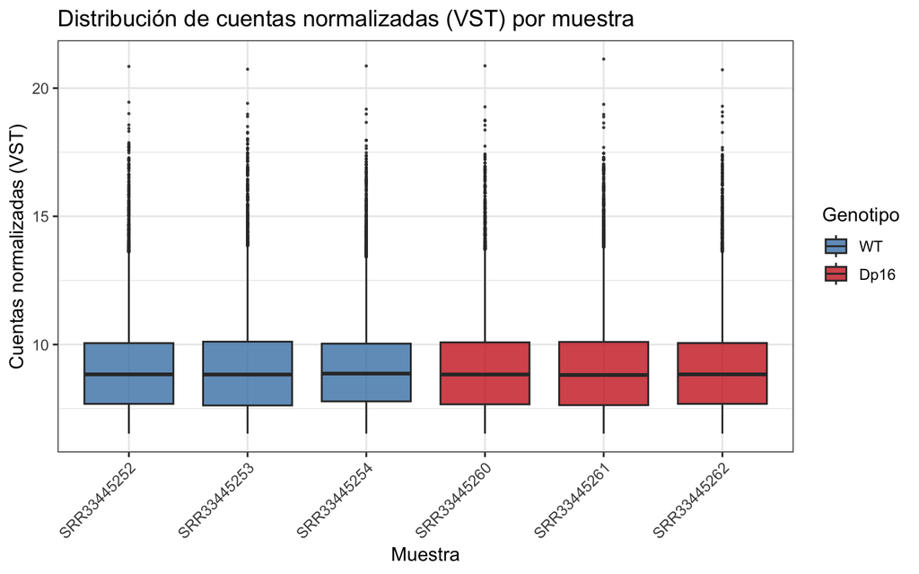

Figura 12. Distribución de cuentas normalizadas (VST, Kallisto) por muestra.

```r
melted_norm_counts <- data.frame(melt(assay(vsd_kallisto)))
colnames(melted_norm_counts) <- c("gene", "sample", "normalized_counts")

melted_norm_counts <- left_join(
  melted_norm_counts,
  data.frame(sample = rownames(metadata), genotype = metadata$genotype),
  by = "sample"
)

ggplot(melted_norm_counts,
       aes(x = sample, y = normalized_counts, fill = genotype)) +
  geom_boxplot(outlier.size = 0.3, alpha = 0.8) +
  scale_fill_manual(values = c("WT" = "steelblue", "Dp16" = "firebrick3")) +
  labs(title = "Distribución de cuentas normalizadas (VST) por muestra",
       x = "Muestra", y = "Cuentas normalizadas (VST)", fill = "Genotipo") +
  theme_bw(base_size = 12) +
  theme(axis.text.x = element_text(angle = 45, hjust = 1),
        plot.background = element_rect(fill = "white"))
```

**Interpretación:** Las medianas de las seis muestras se encuentran alineadas en torno a 9, confirmando que la normalización VST corrigió exitosamente las diferencias de tamaño de librería. Los rangos intercuartílicos son homogéneos entre muestras, sin outliers sistemáticos que indiquen problemas técnicos.

### 2.4 Z-score

```r
counts_raw <- counts(dds)

var_non_zero    <- apply(counts_raw, 1, var) != 0
filtered_counts <- counts_raw[var_non_zero, ]

zscores    <- t(scale(t(filtered_counts)))
zscore_mat <- as.matrix(zscores)

cat("Genes con varianza > 0:", nrow(zscore_mat), "\n")
```

```
## Genes con varianza > 0: 14715
```

```r
cat("Muestras:", ncol(zscore_mat), "\n")
```

```
## Muestras: 6
```

De los ~20,000+ genes del genoma de ratón, 14,715 muestran al menos algo de variación entre las 6 muestras. Estos son los informativos para clustering y heatmaps.

## 3. Análisis exploratorio: PCA

El PCA reduce la dimensionalidad de los datos a componentes que capturan la mayor variación. Su propósito es verificar que las muestras agrupan por la variable biológica de interés (genotipo) y no por variables técnicas.

### 3.1 PCA y Kallisto

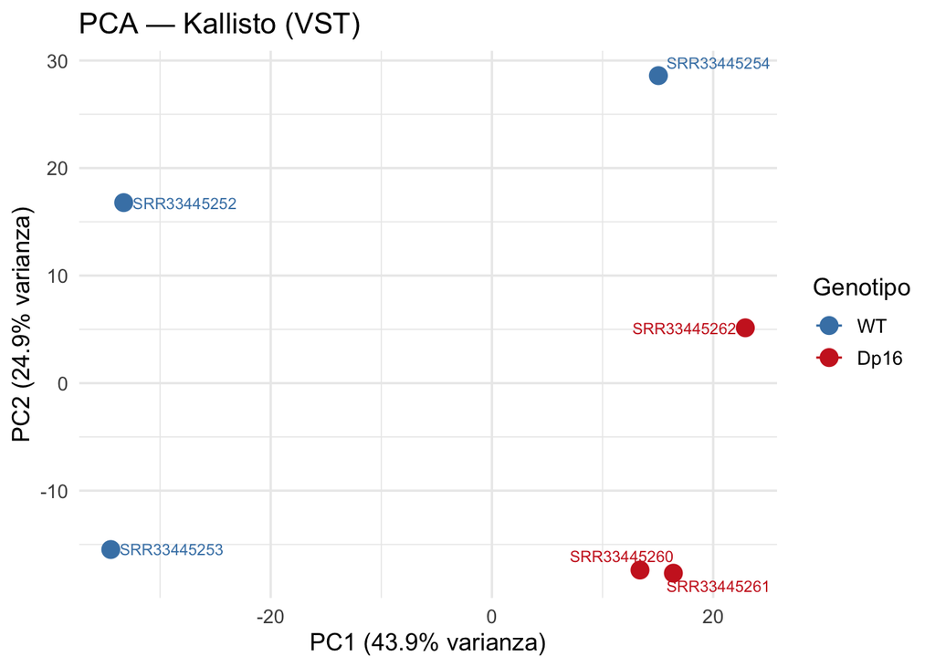

Figura 13. PCA de muestras normalizadas con VST (Kallisto).

```r
mat_k <- assay(vsd_kallisto)
pc_k  <- prcomp(t(mat_k))

var_exp_k <- pc_k$sdev^2 / sum(pc_k$sdev^2) * 100

pca_df_k <- data.frame(
  PC1      = pc_k$x[, 1],
  PC2      = pc_k$x[, 2],
  genotype = metadata$genotype,
  sample   = rownames(metadata)
)

ggplot(pca_df_k, aes(x = PC1, y = PC2, color = genotype, label = sample)) +
  geom_point(size = 4) +
  geom_text_repel(size = 3, show.legend = FALSE) +
  stat_ellipse(aes(group = genotype), linetype = "dashed", level = 0.8) +
  scale_color_manual(values = c("WT" = "steelblue", "Dp16" = "firebrick3")) +
  labs(title = "PCA — Kallisto (VST)",
       x     = sprintf("PC1 (%.1f%% varianza)", var_exp_k[1]),
       y     = sprintf("PC2 (%.1f%% varianza)", var_exp_k[2]),
       color = "Genotipo") +
  theme_minimal(base_size = 13) +
  theme(plot.background = element_rect(fill = "white"))
```

### 3.2 Scree Plot

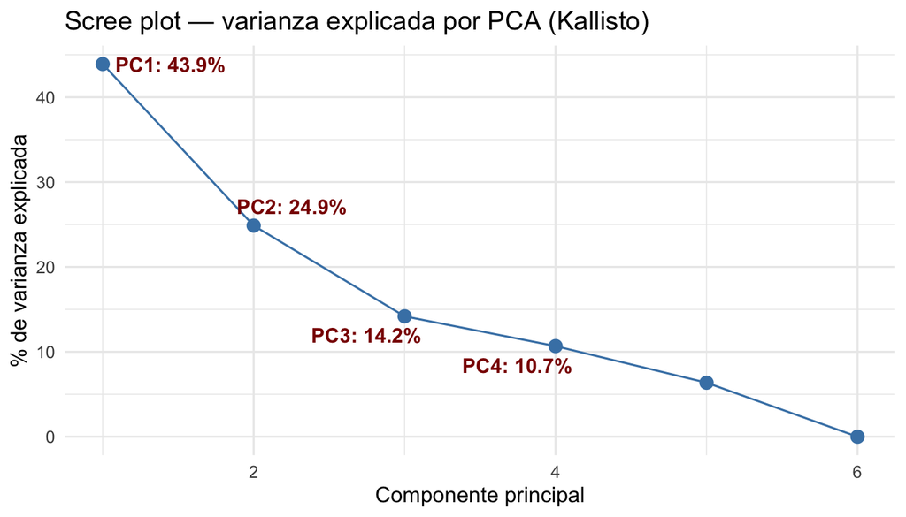

Figura 14. Scree plot: porcentaje de varianza explicada por cada componente principal (Kallisto).

```r
df_scree <- data.frame(
  Componente = seq_along(var_exp_k),
  Varianza   = var_exp_k,
  Etiqueta   = paste0("PC", seq_along(var_exp_k), ": ",
                      round(var_exp_k, 1), "%")
)

ggplot(df_scree, aes(x = Componente, y = Varianza)) +
  geom_point(color = "steelblue", size = 3) +
  geom_line(color = "steelblue") +
  geom_text_repel(data = df_scree[1:4, ],
                  aes(label = Etiqueta),
                  size = 4, color = "darkred", fontface = "bold",
                  box.padding = 0.4) +
  labs(title = "Scree plot — varianza explicada por PCA (Kallisto)",
       x = "Componente principal",
       y = "% de varianza explicada") +
  theme_minimal(base_size = 12) +
  theme(plot.background = element_rect(fill = "white"))
```

### 3.3 PCA y STAR

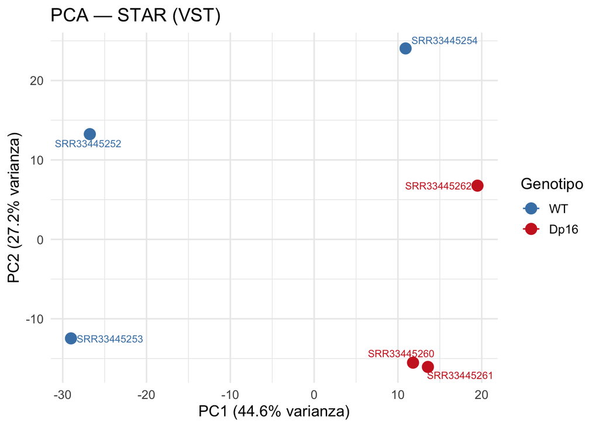

Figura 15. PCA de muestras normalizadas con VST (STAR).

```r
mat_s <- assay(vsd_star)
pc_s  <- prcomp(t(mat_s))

var_exp_s <- pc_s$sdev^2 / sum(pc_s$sdev^2) * 100

pca_df_s <- data.frame(
  PC1      = pc_s$x[, 1],
  PC2      = pc_s$x[, 2],
  genotype = metadata$genotype,
  sample   = rownames(metadata)
)

ggplot(pca_df_s, aes(x = PC1, y = PC2, color = genotype, label = sample)) +
  geom_point(size = 4) +
  geom_text_repel(size = 3, show.legend = FALSE) +
  stat_ellipse(aes(group = genotype), linetype = "dashed", level = 0.8) +
  scale_color_manual(values = c("WT" = "steelblue", "Dp16" = "firebrick3")) +
  labs(title = "PCA — STAR (VST)",
       x     = sprintf("PC1 (%.1f%% varianza)", var_exp_s[1]),
       y     = sprintf("PC2 (%.1f%% varianza)", var_exp_s[2]),
       color = "Genotipo") +
  theme_minimal(base_size = 13) +
  theme(plot.background = element_rect(fill = "white"))
```

### 3.4 Corrección de batch effect

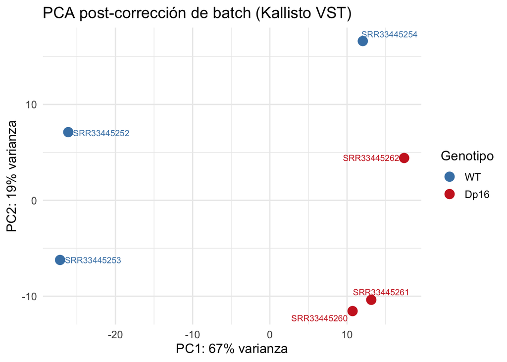

Figura 16. PCA post-corrección de batch effect (Kallisto VST).

```r
vsd_bc    <- vsd_kallisto
mm_design <- model.matrix(~ genotype, colData(vsd_bc))
mat_bc    <- assay(vsd_bc)
mat_bc    <- removeBatchEffect(mat_bc, design = mm_design)
assay(vsd_bc) <- mat_bc

pcaData_bc    <- plotPCA(vsd_bc, intgroup = "genotype", returnData = TRUE)
percentVar_bc <- round(100 * attr(pcaData_bc, "percentVar"))

ggplot(pcaData_bc, aes(PC1, PC2, color = genotype, label = name)) +
  geom_point(size = 4) +
  geom_text_repel(size = 3, show.legend = FALSE) +
  scale_color_manual(values = c("WT" = "steelblue", "Dp16" = "firebrick3")) +
  labs(title = "PCA post-corrección de batch (Kallisto VST)",
       x = paste0("PC1: ", percentVar_bc[1], "% varianza"),
       y = paste0("PC2: ", percentVar_bc[2], "% varianza"),
       color = "Genotipo") +
  theme_minimal(base_size = 13) +
  theme(plot.background = element_rect(fill = "white"))
```

> **Nota importante:** Esta corrección es **únicamente para visualización**. El análisis diferencial con DESeq2 siempre se corre sobre los datos originales sin corregir.

## 4. Análisis de Expresión Diferencial (DESeq2)

DESeq2 modela las cuentas con una distribución binomial negativa. El análisis realiza tres pasos: (1) estimación de **factores de tamaño**, (2) estimación de la **dispersión** gen a gen, y (3) ajuste del modelo lineal generalizado y prueba de Wald para obtener log2FC y p-values.

### 4.1 DESeq2 y Kallisto

```r
dds$genotype <- relevel(dds$genotype, ref = "WT")
dds <- DESeq(dds)
resultsNames(dds)
```

```
## [1] "Intercept"           "genotype_Dp16_vs_WT"
```

```r
res_kallisto <- results(dds,
                        contrast = c("genotype", "Dp16", "WT"),
                        alpha    = 0.05)
summary(res_kallisto)
```

```
##
## out of 14715 with nonzero total read count
## adjusted p-value < 0.05
## LFC > 0 (up)       : 171, 1.2%
## LFC < 0 (down)     : 229, 1.6%
## outliers [1]       : 17, 0.12%
## low counts [2]     : 0, 0%
## (mean count < 5)
## [1] see 'cooksCutoff' argument of ?results
## [2] see 'independentFiltering' argument of ?results
```

### 4.2 Shrinkage de log2FC y Kallisto

```r
res_kallisto_shrink <- lfcShrink(dds,
                                 coef = "genotype_Dp16_vs_WT",
                                 type = "apeglm")
summary(res_kallisto_shrink)
```

```
##
## out of 14715 with nonzero total read count
## adjusted p-value < 0.1
## LFC > 0 (up)       : 240, 1.6%
## LFC < 0 (down)     : 297, 2%
## outliers [1]       : 17, 0.12%
## low counts [2]     : 0, 0%
## (mean count < 5)
## [1] see 'cooksCutoff' argument of ?results
## [2] see 'independentFiltering' argument of ?results
```

### 4.3 DESeq2 y STAR

```r
dds_star$genotype <- relevel(dds_star$genotype, ref = "WT")
dds_star <- DESeq(dds_star)
resultsNames(dds_star)
```

```
## [1] "Intercept"           "genotype_Dp16_vs_WT"
```

```r
res_star <- results(dds_star,
                    contrast = c("genotype", "Dp16", "WT"),
                    alpha    = 0.05)
summary(res_star)
```

```
##
## out of 14091 with nonzero total read count
## adjusted p-value < 0.05
## LFC > 0 (up)       : 152, 1.1%
## LFC < 0 (down)     : 211, 1.5%
## outliers [1]       : 10, 0.071%
## low counts [2]     : 0, 0%
## (mean count < 5)
## [1] see 'cooksCutoff' argument of ?results
## [2] see 'independentFiltering' argument of ?results
```

```r
res_star_shrink <- lfcShrink(dds_star,
                              coef = "genotype_Dp16_vs_WT",
                              type = "apeglm")
summary(res_star_shrink)
```

```
##
## out of 14091 with nonzero total read count
## adjusted p-value < 0.1
## LFC > 0 (up)       : 237, 1.7%
## LFC < 0 (down)     : 289, 2.1%
## outliers [1]       : 10, 0.071%
## low counts [2]     : 0, 0%
## (mean count < 5)
## [1] see 'cooksCutoff' argument of ?results
## [2] see 'independentFiltering' argument of ?results
```

### 4.4 Tabla comparativa de DEGs

```r
sig_kallisto <- as.data.frame(res_kallisto_shrink) %>%
  filter(!is.na(padj) & padj < 0.05)

sig_star <- as.data.frame(res_star_shrink) %>%
  filter(!is.na(padj) & padj < 0.05)

resumen <- data.frame(
  Alineador      = c("Kallisto", "STAR"),
  Genes_totales  = c(nrow(dds), nrow(dds_star)),
  DEGs_total     = c(nrow(sig_kallisto), nrow(sig_star)),
  Up_regulated   = c(sum(sig_kallisto$log2FoldChange > 0),
                     sum(sig_star$log2FoldChange > 0)),
  Down_regulated = c(sum(sig_kallisto$log2FoldChange < 0),
                     sum(sig_star$log2FoldChange < 0))
)

kable(resumen,
      col.names = c("Alineador", "Genes totales", "DEGs (padj<0.05)",
                    "Up-regulated", "Down-regulated"),
      caption = "Tabla 10. Resumen de genes diferencialmente expresados por alineador (Dp16 vs WT, padj < 0.05).") %>%
  kable_styling(bootstrap_options = c("striped","hover","condensed"),
                full_width = FALSE)
```

Tabla 10. Resumen de genes diferencialmente expresados por alineador (Dp16 vs WT, padj < 0.05).

| Alineador | Genes totales | DEGs (padj<0.05) | Up-regulated | Down-regulated |
| --- | --- | --- | --- | --- |
| Kallisto | 14715 | 400 | 171 | 229 |
| STAR | 14091 | 363 | 152 | 211 |

**Interpretación:** El análisis diferencial identificó 400 DEGs en Kallisto y 363 en STAR (padj < 0.05), con un balance consistente: ~57% reprimidos en Dp16 y ~43% activados. La concordancia entre Kallisto y STAR (~90%) indica que el patrón es robusto e independiente del método de cuantificación.

## 5. Top genes más significativos

### Top 20 DEGs — Kallisto

```r
top20_k <- sig_kallisto %>%
  arrange(padj) %>%
  head(20) %>%
  select(baseMean, log2FoldChange, lfcSE, pvalue, padj) %>%
  mutate(across(where(is.numeric), ~ round(.x, 4)))

kable(top20_k,
      col.names = c("Expr. media", "log2FC", "SE", "p-value", "p-adj"),
      caption = "Tabla 11. Top 20 genes más significativos — Kallisto (Dp16 vs WT, padj < 0.05).") %>%
  kable_styling(bootstrap_options = c("striped","hover","condensed"),
                full_width = FALSE)
```

Tabla 11. Top 20 genes más significativos — Kallisto (Dp16 vs WT, padj < 0.05).

|  | Expr. media | log2FC | SE | p-value | p-adj |
| --- | --- | --- | --- | --- | --- |
| ENSMUSG00000097148.2 | 221.5899 | -3.8684 | 0.4515 | 0 | 0 |
| ENSMUSG00000001665.11 | 2301.2742 | 1.6308 | 0.1995 | 0 | 0 |
| ENSMUSG00000117780.1 | 615.5616 | -3.1112 | 0.3911 | 0 | 0 |
| ENSMUSG00000032080.6 | 13254.4287 | -1.2916 | 0.1689 | 0 | 0 |
| ENSMUSG00000029417.9 | 817.9000 | -1.8694 | 0.2546 | 0 | 0 |
| ENSMUSG00000006494.11 | 3493.7405 | 1.4713 | 0.2022 | 0 | 0 |
| ENSMUSG00000069456.4 | 3868.0862 | 1.3199 | 0.1866 | 0 | 0 |
| ENSMUSG00000094708.1 | 105.7300 | 10.9872 | 3.0280 | 0 | 0 |
| ENSMUSG00000095937.1 | 105.7300 | 10.9872 | 3.0280 | 0 | 0 |
| ENSMUSG00000029822.15 | 127.7477 | -2.3736 | 0.3493 | 0 | 0 |
| ENSMUSG00000057074.6 | 6673.3986 | 1.0001 | 0.1484 | 0 | 0 |
| ENSMUSG00000078606.8 | 488.7620 | -1.4457 | 0.2314 | 0 | 0 |
| ENSMUSG00000027596.10 | 39.5124 | -9.6737 | 2.9575 | 0 | 0 |
| ENSMUSG00000037827.5 | 45.5567 | 9.5875 | 2.8760 | 0 | 0 |
| ENSMUSG00000095597.2 | 40.6972 | 9.4140 | 2.8425 | 0 | 0 |
| ENSMUSG00000024899.7 | 9075.8872 | 0.8624 | 0.1441 | 0 | 0 |
| ENSMUSG00000078922.9 | 427.4633 | -2.1887 | 0.3718 | 0 | 0 |
| ENSMUSG00000074240.5 | 144.8147 | -4.3150 | 0.7433 | 0 | 0 |
| ENSMUSG00000090381.2 | 41.3654 | -5.4125 | 0.9232 | 0 | 0 |
| ENSMUSG00000063590.3 | 94.0080 | -4.3512 | 0.7631 | 0 | 0 |

### Top 20 DEGs — STAR

```r
top20_s <- sig_star %>%
  arrange(padj) %>%
  head(20) %>%
  select(baseMean, log2FoldChange, lfcSE, pvalue, padj) %>%
  mutate(across(where(is.numeric), ~ round(.x, 4)))

kable(top20_s,
      col.names = c("Expr. media", "log2FC", "SE", "p-value", "p-adj"),
      caption = "Tabla 12. Top 20 genes más significativos — STAR (Dp16 vs WT, padj < 0.05).") %>%
  kable_styling(bootstrap_options = c("striped","hover","condensed"),
                full_width = FALSE)
```

Tabla 12. Top 20 genes más significativos — STAR (Dp16 vs WT, padj < 0.05).

|  | Expr. media | log2FC | SE | p-value | p-adj |
| --- | --- | --- | --- | --- | --- |
| ENSMUSG00000117780.1 | 624.4800 | -3.3229 | 0.3469 | 0 | 0 |
| ENSMUSG00000029417.9 | 772.7797 | -1.8147 | 0.1940 | 0 | 0 |
| ENSMUSG00000097148.2 | 186.4670 | -3.8658 | 0.4495 | 0 | 0 |
| ENSMUSG00000001665.11 | 1001.2573 | 1.5612 | 0.1837 | 0 | 0 |
| ENSMUSG00000069456.4 | 3676.6815 | 1.3136 | 0.1731 | 0 | 0 |
| ENSMUSG00000057074.6 | 6515.7780 | 1.0052 | 0.1393 | 0 | 0 |
| ENSMUSG00000032080.6 | 2017.0016 | -1.2743 | 0.1793 | 0 | 0 |
| ENSMUSG00000024411.11 | 72.6810 | -2.6860 | 0.4011 | 0 | 0 |
| ENSMUSG00000021416.11 | 57.1663 | 5.8161 | 0.8390 | 0 | 0 |
| ENSMUSG00000015090.13 | 61.9050 | 3.7672 | 0.5926 | 0 | 0 |
| ENSMUSG00000040938.16 | 392.8636 | 1.3553 | 0.2179 | 0 | 0 |
| ENSMUSG00000056131.13 | 325.1514 | -1.3199 | 0.2152 | 0 | 0 |
| ENSMUSG00000023057.5 | 858.5779 | -0.9842 | 0.1614 | 0 | 0 |
| ENSMUSG00000020926.16 | 202.3003 | 2.4592 | 0.4055 | 0 | 0 |
| ENSMUSG00000028359.4 | 228.2812 | 2.3011 | 0.3817 | 0 | 0 |
| ENSMUSG00000034220.7 | 244.6405 | -2.5862 | 0.4312 | 0 | 0 |
| ENSMUSG00000074240.5 | 149.4177 | -4.2809 | 0.7191 | 0 | 0 |
| ENSMUSG00000024899.7 | 9192.1437 | 0.8076 | 0.1360 | 0 | 0 |
| ENSMUSG00000078922.9 | 151.4595 | -1.9564 | 0.3323 | 0 | 0 |
| ENSMUSG00000027596.10 | 28.4416 | -9.1148 | 2.8936 | 0 | 0 |

## 6. Visualización de resultados

### 6.1 Volcano Plot — Kallisto

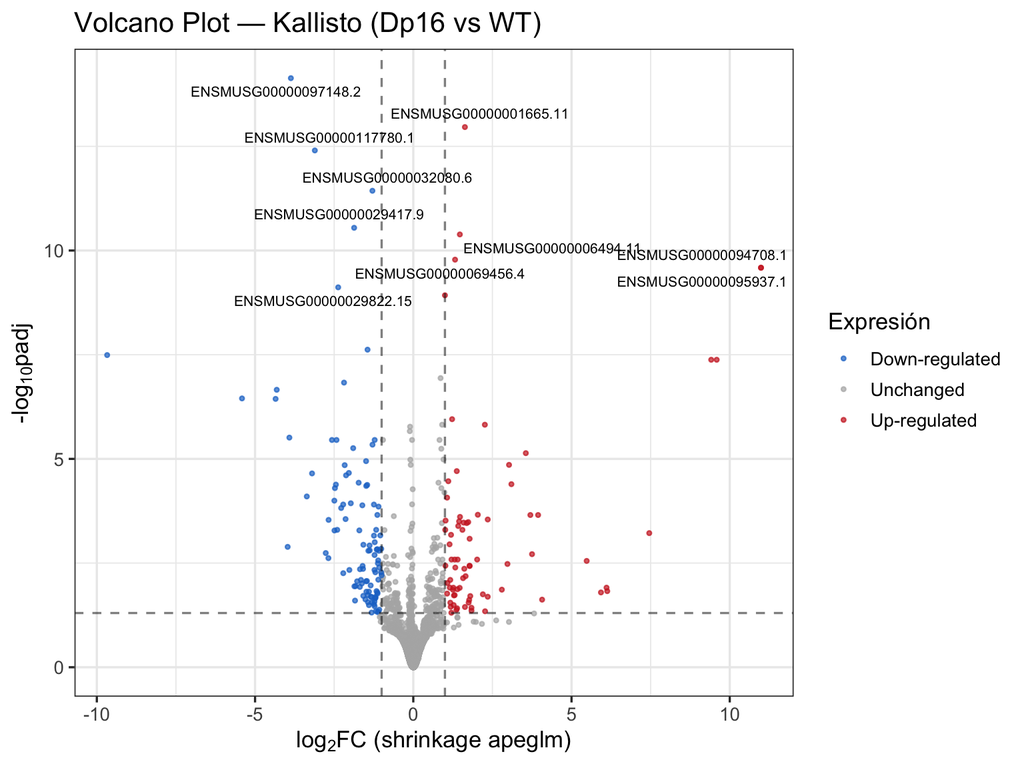

Figura 17. Volcano plot — Kallisto (Dp16 vs WT).

```r
df_k <- as.data.frame(res_kallisto_shrink) %>%
  mutate(
    gene       = rownames(.),
    Expression = case_when(
      log2FoldChange >= 1  & padj < 0.05 ~ "Up-regulated",
      log2FoldChange <= -1 & padj < 0.05 ~ "Down-regulated",
      TRUE ~ "Unchanged"
    )
  )

top_labels_k <- df_k %>%
  filter(Expression != "Unchanged") %>%
  arrange(padj) %>%
  head(10)

ggplot(df_k, aes(x = log2FoldChange, y = -log10(padj))) +
  geom_point(aes(color = Expression), size = 0.8, alpha = 0.7) +
  geom_text_repel(data = top_labels_k, aes(label = gene),
                  size = 2.8, max.overlaps = 15, show.legend = FALSE) +
  scale_color_manual(values = c("Up-regulated"   = "firebrick3",
                                "Down-regulated" = "dodgerblue3",
                                "Unchanged"      = "gray70")) +
  geom_vline(xintercept = c(-1, 1), linetype = "dashed", alpha = 0.5) +
  geom_hline(yintercept = -log10(0.05), linetype = "dashed", alpha = 0.5) +
  labs(title = "Volcano Plot — Kallisto (Dp16 vs WT)",
       x     = expression("log"[2]*"FC (shrinkage apeglm)"),
       y     = expression("-log"[10]*"padj"),
       color = "Expresión") +
  theme_bw(base_size = 13) +
  theme(plot.background = element_rect(fill = "white"))
```

**Interpretación:** Los genes más significativos y con mayor cambio se concentran en ambas esquinas superiores. Los genes down-regulated más significativos (ENSMUSG00000097148.2, ENSMUSG00000117780.1) tienen log2FC entre -3 y -4, indicando una reducción de 8 a 16 veces respecto a WT.

### 6.2 Volcano Plot — STAR

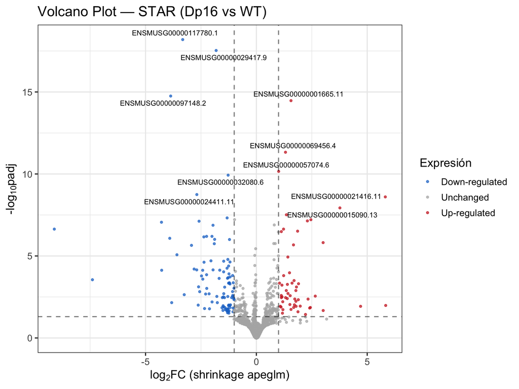

Figura 18. Volcano plot — STAR (Dp16 vs WT).

```r
df_s <- as.data.frame(res_star_shrink) %>%
  mutate(
    gene       = rownames(.),
    Expression = case_when(
      log2FoldChange >= 1  & padj < 0.05 ~ "Up-regulated",
      log2FoldChange <= -1 & padj < 0.05 ~ "Down-regulated",
      TRUE ~ "Unchanged"
    )
  )

top_labels_s <- df_s %>%
  filter(Expression != "Unchanged") %>%
  arrange(padj) %>%
  head(10)

ggplot(df_s, aes(x = log2FoldChange, y = -log10(padj))) +
  geom_point(aes(color = Expression), size = 0.8, alpha = 0.7) +
  geom_text_repel(data = top_labels_s, aes(label = gene),
                  size = 2.8, max.overlaps = 15, show.legend = FALSE) +
  scale_color_manual(values = c("Up-regulated"   = "firebrick3",
                                "Down-regulated" = "dodgerblue3",
                                "Unchanged"      = "gray70")) +
  geom_vline(xintercept = c(-1, 1), linetype = "dashed", alpha = 0.5) +
  geom_hline(yintercept = -log10(0.05), linetype = "dashed", alpha = 0.5) +
  labs(title = "Volcano Plot — STAR (Dp16 vs WT)",
       x     = expression("log"[2]*"FC (shrinkage apeglm)"),
       y     = expression("-log"[10]*"padj"),
       color = "Expresión") +
  theme_bw(base_size = 13) +
  theme(plot.background = element_rect(fill = "white"))
```

**Interpretación:** El patrón es concordante con Kallisto — los mismos genes (ENSMUSG00000117780.1, ENSMUSG00000029417.9, ENSMUSG00000097148.2) aparecen entre los más significativos en ambos alineadores, confirmando señales biológicas reales.

### 6.3 MA Plot — Kallisto

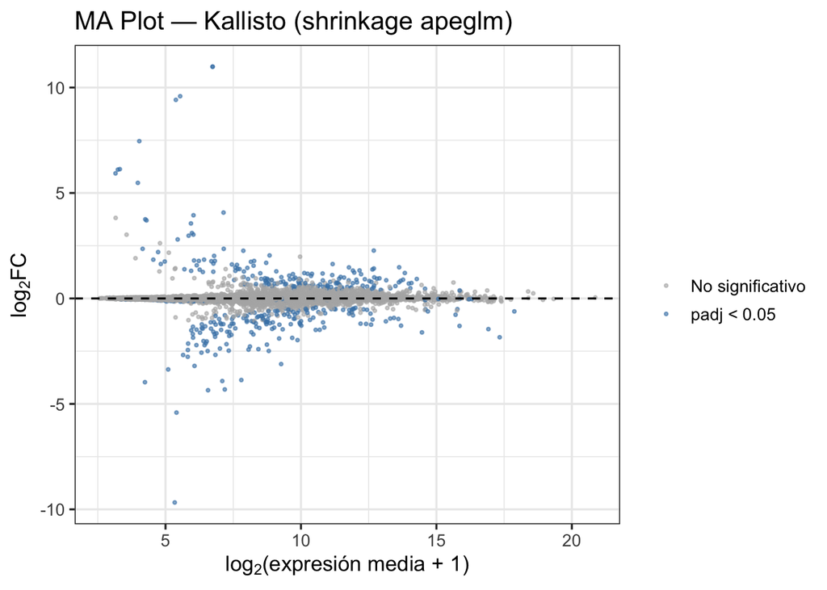

Figura 19. MA plot — Kallisto (shrinkage apeglm).

```r
ma_k <- as.data.frame(res_kallisto_shrink) %>%
  mutate(
    significant  = !is.na(padj) & padj < 0.05,
    baseMean_log = log2(baseMean + 1)
  )

ggplot(ma_k, aes(x = baseMean_log, y = log2FoldChange, color = significant)) +
  geom_point(size = 0.6, alpha = 0.6) +
  scale_color_manual(values = c("FALSE" = "gray70", "TRUE" = "steelblue"),
                     labels = c("No significativo", "padj < 0.05")) +
  geom_hline(yintercept = 0, linetype = "dashed", color = "black") +
  labs(title = "MA Plot — Kallisto (shrinkage apeglm)",
       x     = expression("log"[2]*"(expresión media + 1)"),
       y     = expression("log"[2]*"FC"),
       color = "") +
  theme_bw(base_size = 13) +
  theme(plot.background = element_rect(fill = "white"))
```

**Interpretación:** Los puntos grises están centrados en log2FC = 0 a lo largo de todo el rango de expresión, confirmando que la normalización no introdujo sesgos sistemáticos.

### 6.4 MA Plot — STAR

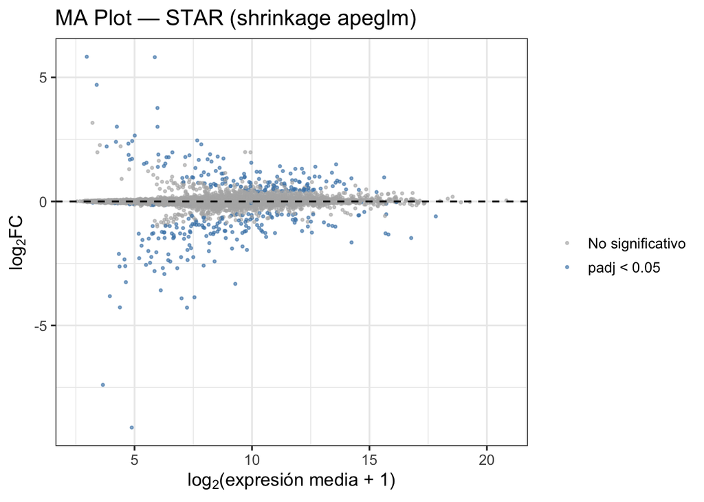

Figura 20. MA plot — STAR (shrinkage apeglm).

```r
ma_s <- as.data.frame(res_star_shrink) %>%
  mutate(
    significant  = !is.na(padj) & padj < 0.05,
    baseMean_log = log2(baseMean + 1)
  )

ggplot(ma_s, aes(x = baseMean_log, y = log2FoldChange, color = significant)) +
  geom_point(size = 0.6, alpha = 0.6) +
  scale_color_manual(values = c("FALSE" = "gray70", "TRUE" = "steelblue"),
                     labels = c("No significativo", "padj < 0.05")) +
  geom_hline(yintercept = 0, linetype = "dashed", color = "black") +
  labs(title = "MA Plot — STAR (shrinkage apeglm)",
       x     = expression("log"[2]*"(expresión media + 1)"),
       y     = expression("log"[2]*"FC"),
       color = "") +
  theme_bw(base_size = 13) +
  theme(plot.background = element_rect(fill = "white"))
```

**Interpretación:** El patrón es prácticamente idéntico al de Kallisto, con DEGs distribuidos simétricamente alrededor de log2FC = 0.

### 6.5 Heatmap — Top 20 DEGs (Kallisto)

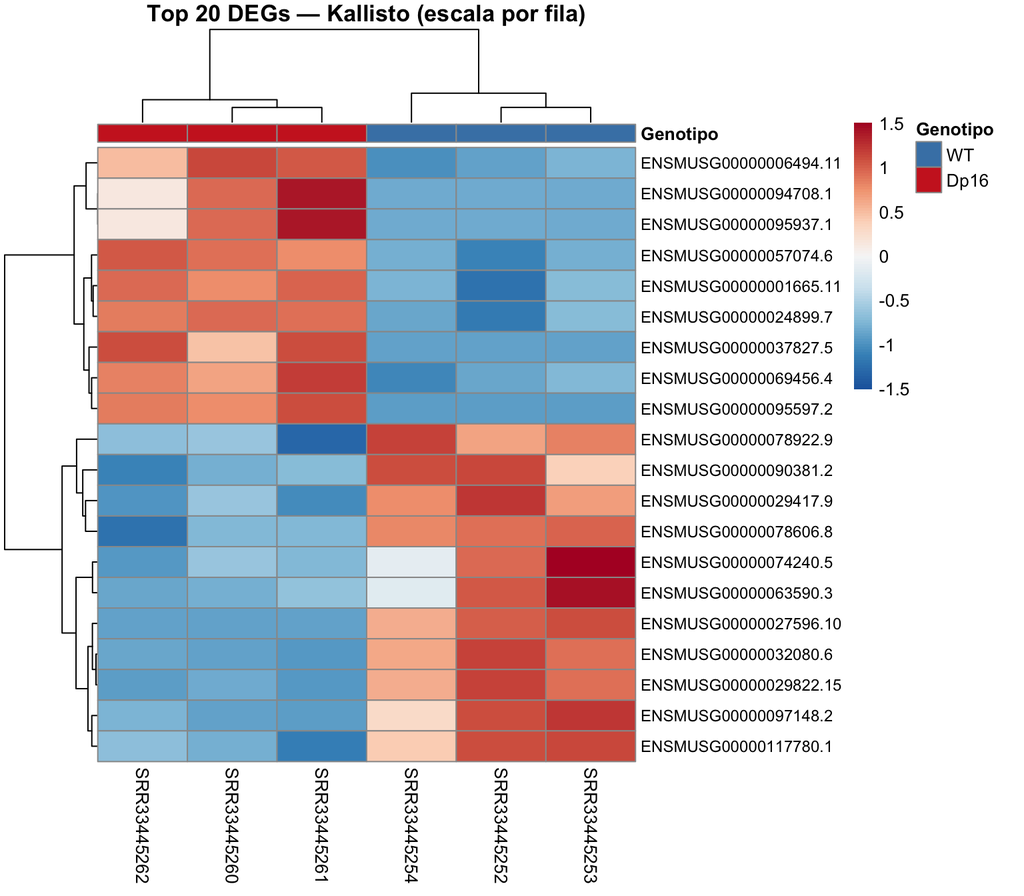

Figura 21. Heatmap de los 20 genes con menor padj — Kallisto (VST, escalado por fila).

```r
top_genes_k <- head(order(res_kallisto$padj, na.last = TRUE), 20)
mat_heat_k  <- assay(vsd_kallisto)[top_genes_k, ]

ann_col    <- data.frame(Genotipo = metadata$genotype)
rownames(ann_col) <- rownames(metadata)
ann_colors <- list(Genotipo = c("WT" = "steelblue", "Dp16" = "firebrick3"))

pheatmap(mat_heat_k,
         cluster_rows      = TRUE,
         cluster_cols      = TRUE,
         show_rownames     = TRUE,
         show_colnames     = TRUE,
         annotation_col    = ann_col,
         annotation_colors = ann_colors,
         scale             = "row",
         color             = colorRampPalette(rev(brewer.pal(9, "RdBu")))(100),
         fontsize_row      = 9,
         main              = "Top 20 DEGs — Kallisto (escala por fila)")
```

**Interpretación:** El clustering jerárquico no supervisado agrupa correctamente las tres réplicas Dp16 separadas de las tres réplicas WT, confirmando que los 20 genes más significativos son suficientes para distinguir ambos genotipos.

### 6.6 Heatmap — Top 20 DEGs (STAR)

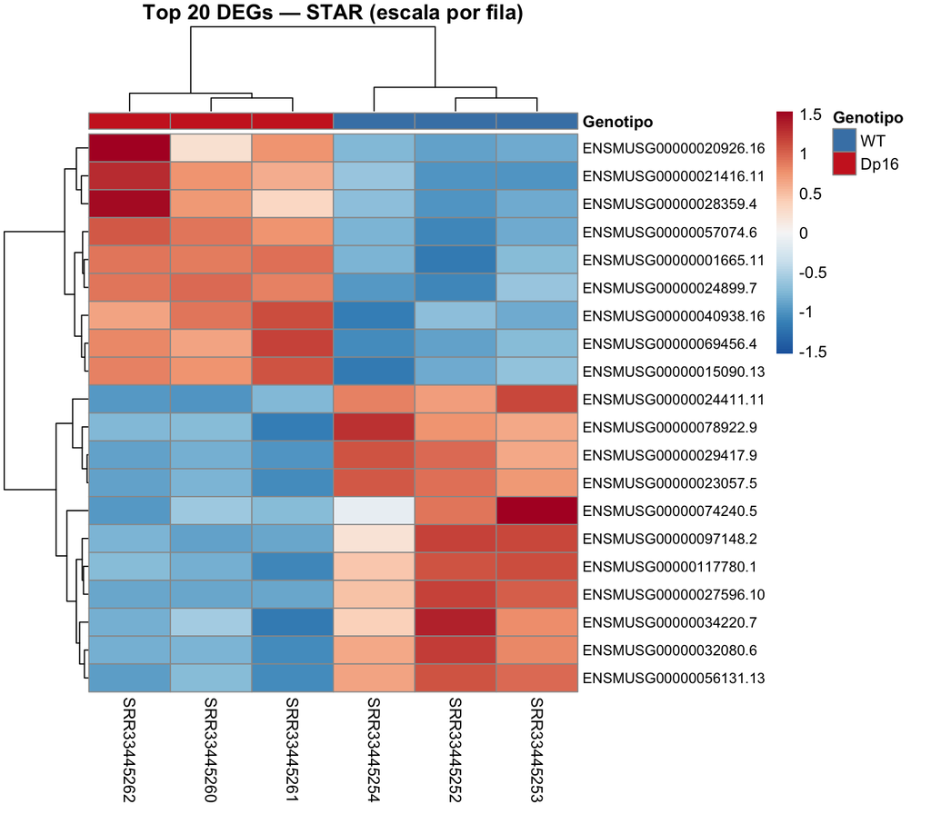

Figura 22. Heatmap de los 20 genes con menor padj — STAR (VST, escalado por fila).

```r
top_genes_s <- head(order(res_star$padj, na.last = TRUE), 20)
mat_heat_s  <- assay(vsd_star)[top_genes_s, ]

pheatmap(mat_heat_s,
         cluster_rows      = TRUE,
         cluster_cols      = TRUE,
         show_rownames     = TRUE,
         show_colnames     = TRUE,
         annotation_col    = ann_col,
         annotation_colors = ann_colors,
         scale             = "row",
         color             = colorRampPalette(rev(brewer.pal(9, "RdBu")))(100),
         fontsize_row      = 9,
         main              = "Top 20 DEGs — STAR (escala por fila)")
```

**Interpretación:** El patrón de clustering es idéntico — Dp16 a la izquierda, WT a la derecha — y varios genes se repiten entre ambos top 20 (ENSMUSG00000001665.11, ENSMUSG00000069456.4, ENSMUSG00000029417.9, ENSMUSG00000074240.5).

## 7. Comparación Kallisto vs STAR

### 7.1 Genes compartidos y exclusivos

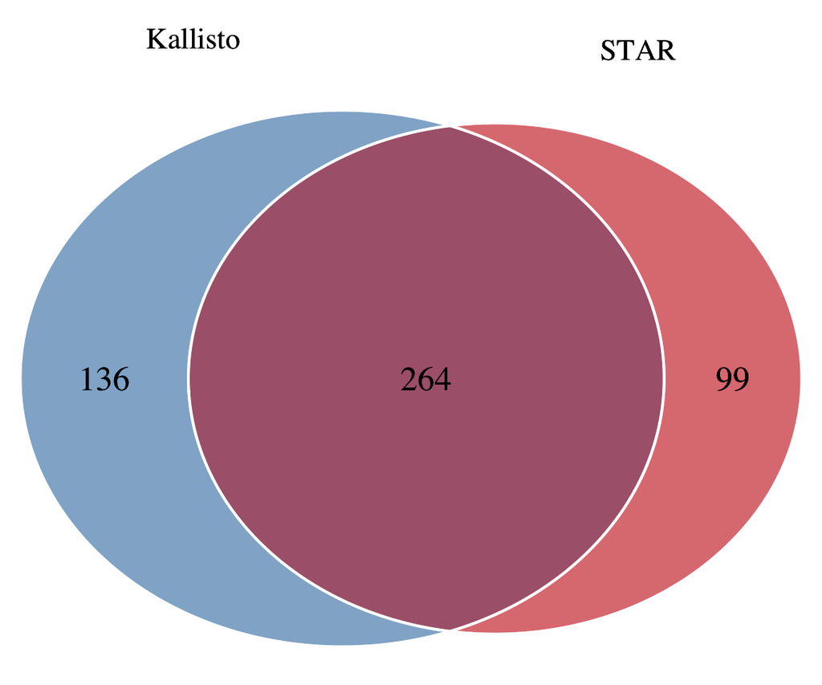

Figura 23. Diagrama de Venn: DEGs compartidos entre Kallisto y STAR (padj < 0.05).

```r
genes_kallisto <- rownames(sig_kallisto)
genes_star     <- rownames(sig_star)

genes_comunes <- intersect(genes_kallisto, genes_star)
genes_solo_k  <- setdiff(genes_kallisto, genes_star)
genes_solo_s  <- setdiff(genes_star, genes_kallisto)

venn.plot <- draw.pairwise.venn(
  area1      = length(genes_kallisto),
  area2      = length(genes_star),
  cross.area = length(genes_comunes),
  category   = c("Kallisto", "STAR"),
  fill       = c("steelblue", "firebrick3"),
  alpha      = 0.4,
  col        = "white",
  cex        = 1.5,
  cat.cex    = 1.3,
  cat.pos    = c(-20, 20),
  cat.dist   = 0.07
)
grid.draw(venn.plot)
```

```r
venn_resumen <- data.frame(
  Categoría = c("Solo Kallisto", "Compartidos", "Solo STAR"),
  N_genes   = c(length(genes_solo_k), length(genes_comunes), length(genes_solo_s))
)

kable(venn_resumen,
      caption = "Tabla 13. Distribución de DEGs entre alineadores (padj < 0.05).") %>%
  kable_styling(bootstrap_options = c("striped","hover","condensed"),
                full_width = FALSE)
```

Tabla 13. Distribución de DEGs entre alineadores (padj < 0.05).

| Categoría | N_genes |
| --- | --- |
| Solo Kallisto | 136 |
| Compartidos | 264 |
| Solo STAR | 99 |

## 8. Análisis Funcional y GO terms con gprofiler2

gprofiler2 implementa una prueba hipergeométrica que evalúa si la proporción de genes de una categoría GO/KEGG/REAC en nuestra lista de DEGs es mayor de lo esperado por azar. Usamos los genes **compartidos entre Kallisto y STAR** para maximizar la confiabilidad biológica.

### 8.1 Preparar listas de genes

```r
up_genes   <- genes_comunes[sig_kallisto[genes_comunes, "log2FoldChange"] > 0]
down_genes <- genes_comunes[sig_kallisto[genes_comunes, "log2FoldChange"] < 0]

up_genes   <- up_genes[!is.na(up_genes)]
down_genes <- down_genes[!is.na(down_genes)]

up_genes   <- gsub("\\..*", "", up_genes)
down_genes <- gsub("\\..*", "", down_genes)

cat("Genes up-regulated (compartidos):", length(up_genes), "\n")
```

```
## Genes up-regulated (compartidos): 113
```

```r
cat("Genes down-regulated (compartidos):", length(down_genes), "\n")
```

```
## Genes down-regulated (compartidos): 151
```

```r
head(up_genes)
```

```
## [1] "ENSMUSG00000001665" "ENSMUSG00000002588" "ENSMUSG00000002847"
## [4] "ENSMUSG00000003477" "ENSMUSG00000005373" "ENSMUSG00000005677"
```

```r
head(down_genes)
```

```
## [1] "ENSMUSG00000000159" "ENSMUSG00000000303" "ENSMUSG00000000915"
## [4] "ENSMUSG00000001506" "ENSMUSG00000001763" "ENSMUSG00000002033"
```

### 8.2 Enriquecimiento con gprofiler2

```r
sources_db <- c("GO:BP", "GO:MF", "GO:CC", "KEGG", "REAC")

multi_gp <- gost(
  query = list(
    "Up-regulated"   = up_genes,
    "Down-regulated" = down_genes
  ),
  organism          = "mmusculus",
  correction_method = "fdr",
  user_threshold    = 0.05,
  multi_query       = FALSE,
  ordered_query     = FALSE,
  sources           = sources_db,
  evcodes           = TRUE
)

cat("Columnas del resultado:", paste(colnames(multi_gp$result), collapse = ", "), "\n")
```

```
## Columnas del resultado: query, significant, p_value, term_size, query_size, intersection_size, precision, recall, term_id, source, term_name, effective_domain_size, source_order, parents, evidence_codes, intersection
```

```r
cat("Queries:", paste(unique(multi_gp$result$query), collapse = ", "), "\n")
```

```
## Queries: Down-regulated, Up-regulated
```

```r
cat("Términos enriquecidos totales:", nrow(multi_gp$result), "\n")
```

```
## Términos enriquecidos totales: 720
```

### 8.3 Manhattan plot

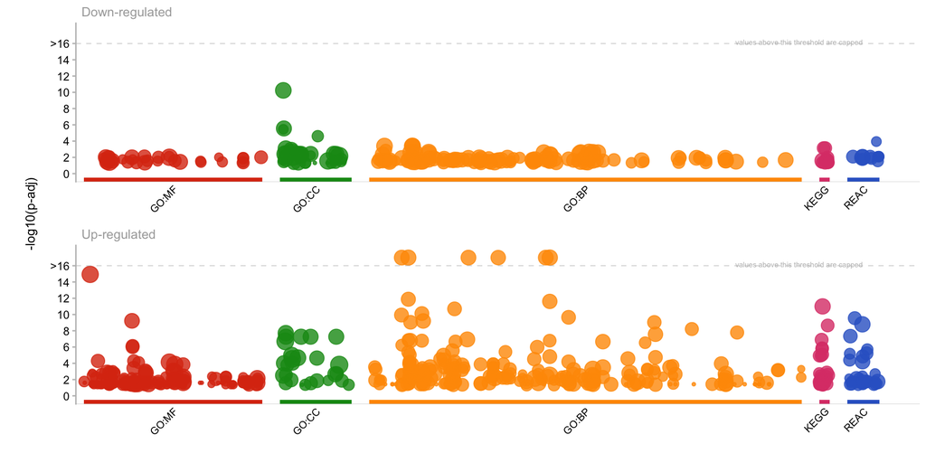

Figura 24. Manhattan plot de términos GO, KEGG y REAC enriquecidos en los genes DEG compartidos (FDR < 0.05).

```r
gostplot(multi_gp, interactive = FALSE)
```

### 8.4 Top términos enriquecidos — Up-regulated

```r
if (!is.null(multi_gp$result)) {
  gost_df <- as.data.frame(multi_gp$result)

  bar_up <- gost_df %>%
    filter(query == "Up-regulated") %>%
    arrange(p_value) %>%
    head(20) %>%
    select(term_name, source, term_size, intersection_size, p_value) %>%
    mutate(p_value = formatC(p_value, format = "e", digits = 2))

  kable(bar_up,
        col.names = c("Término GO", "Base de datos", "Tamaño del término",
                      "Genes en overlap", "p-value (FDR)"),
        caption = "Tabla 14. Top 20 términos enriquecidos en genes up-regulated en Dp16 vs WT.") %>%
    kable_styling(bootstrap_options = c("striped","hover","condensed"),
                  full_width = FALSE)
}
```

Tabla 14. Top 20 términos enriquecidos en genes up-regulated en Dp16 vs WT.

| Término GO | Base de datos | Tamaño del término | Genes en overlap | p-value (FDR) |
| --- | --- | --- | --- | --- |
| small molecule metabolic process | GO:BP | 1549 | 44 | 1.54e-23 |
| lipid metabolic process | GO:BP | 1266 | 40 | 7.01e-23 |
| oxoacid metabolic process | GO:BP | 783 | 32 | 5.42e-21 |
| organic acid metabolic process | GO:BP | 789 | 32 | 5.42e-21 |
| carboxylic acid metabolic process | GO:BP | 769 | 30 | 4.36e-19 |
| monocarboxylic acid metabolic process | GO:BP | 549 | 26 | 2.46e-18 |
| catalytic activity | GO:MF | 5584 | 68 | 1.16e-15 |
| fatty acid metabolic process | GO:BP | 357 | 18 | 1.33e-12 |
| small molecule biosynthetic process | GO:BP | 500 | 20 | 2.43e-12 |
| Metabolic pathways | KEGG | 1646 | 40 | 1.00e-11 |
| organic acid biosynthetic process | GO:BP | 251 | 15 | 2.01e-11 |
| steroid metabolic process | GO:BP | 277 | 15 | 7.61e-11 |
| alcohol metabolic process | GO:BP | 287 | 15 | 1.16e-10 |
| carboxylic acid biosynthetic process | GO:BP | 247 | 14 | 2.21e-10 |
| Drug ADME | REAC | 105 | 13 | 2.79e-10 |
| oxidoreductase activity | GO:MF | 742 | 22 | 5.97e-10 |
| lipid biosynthetic process | GO:BP | 610 | 19 | 6.20e-10 |
| sulfur compound metabolic process | GO:BP | 224 | 13 | 9.03e-10 |
| monocarboxylic acid biosynthetic process | GO:BP | 176 | 12 | 9.03e-10 |
| Metabolism | REAC | 1740 | 39 | 1.61e-09 |

**Interpretación:** Los genes activados en Dp16 se enriquecen masivamente en procesos metabólicos hepáticos. Los dos términos más significativos — “small molecule metabolic process” y “lipid metabolic process” — tienen FDR de 1.54e-23 y 7.01e-23 respectivamente. Esto es directamente concordante con lo reportado por Dunn et al. (2026).

### 8.5 Top términos enriquecidos — Down-regulated

```r
if (!is.null(multi_gp$result)) {
  gost_df <- as.data.frame(multi_gp$result)

  bar_down <- gost_df %>%
    filter(query == "Down-regulated") %>%
    arrange(p_value) %>%
    head(20) %>%
    select(term_name, source, term_size, intersection_size, p_value) %>%
    mutate(p_value = formatC(p_value, format = "e", digits = 2))

  kable(bar_down,
        col.names = c("Término GO", "Base de datos", "Tamaño del término",
                      "Genes en overlap", "p-value (FDR)"),
        caption = "Tabla 15. Top 20 términos enriquecidos en genes down-regulated en Dp16 vs WT.") %>%
    kable_styling(bootstrap_options = c("striped","hover","condensed"),
                  full_width = FALSE)
}
```

Tabla 15. Top 20 términos enriquecidos en genes down-regulated en Dp16 vs WT.

| Término GO | Base de datos | Tamaño del término | Genes en overlap | p-value (FDR) |
| --- | --- | --- | --- | --- |
| extracellular region | GO:CC | 2340 | 44 | 5.80e-11 |
| extracellular space | GO:CC | 1136 | 24 | 2.79e-06 |
| membrane attack complex | GO:CC | 7 | 4 | 3.55e-06 |
| pore complex | GO:CC | 26 | 5 | 2.49e-05 |
| Terminal pathway of complement | REAC | 8 | 4 | 1.14e-04 |
| immune system process | GO:BP | 2557 | 33 | 4.06e-04 |
| defense response | GO:BP | 1633 | 25 | 4.06e-04 |
| response to stress | GO:BP | 3596 | 41 | 4.06e-04 |
| immune response | GO:BP | 1726 | 26 | 4.06e-04 |
| PPAR signaling pathway | KEGG | 89 | 7 | 7.17e-04 |
| Complement and coagulation cascades | KEGG | 94 | 7 | 7.17e-04 |
| endoplasmic reticulum | GO:CC | 1758 | 25 | 8.25e-04 |
| cell surface | GO:CC | 753 | 15 | 1.13e-03 |
| humoral immune response mediated by circulating immunoglobulin | GO:BP | 43 | 5 | 1.32e-03 |
| endomembrane system | GO:CC | 4005 | 41 | 2.22e-03 |
| response to external stimulus | GO:BP | 2346 | 29 | 2.27e-03 |
| response to stimulus | GO:BP | 9759 | 74 | 2.49e-03 |
| positive regulation of response to stimulus | GO:BP | 2034 | 26 | 2.49e-03 |
| response to other organism | GO:BP | 1566 | 22 | 2.49e-03 |
| response to external biotic stimulus | GO:BP | 1570 | 22 | 2.49e-03 |

**Interpretación:** Los genes reprimidos en Dp16 muestran dos patrones: proteínas secretadas/matriz extracelular (“extracellular region”, FDR 5.80e-11) e inmunidad humoral (“complement activation”, “immune response”). La presencia de “Complement and coagulation cascades” en KEGG apunta a la represión de la cascada del complemento en el hígado Dp16.

### 8.6 Barplot GO:BP — Up-regulated

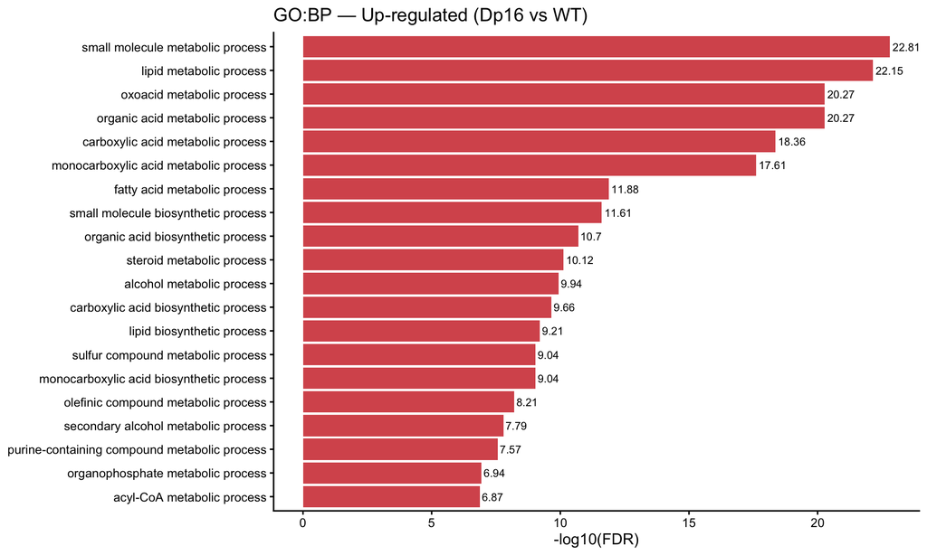

Figura 25. Top 20 procesos biológicos (GO:BP) enriquecidos en genes up-regulated en Dp16 vs WT.

```r
if (!is.null(multi_gp$result)) {
  gost_df <- as.data.frame(multi_gp$result)

  bar_up_plot <- gost_df %>%
    filter(query == "Up-regulated", source == "GO:BP") %>%
    arrange(p_value) %>%
    head(20) %>%
    mutate(log10p = round(-log10(p_value), 2),
           num    = seq_len(n()))

  if (nrow(bar_up_plot) > 0) {
    ggplot(bar_up_plot,
           aes(x = log10p, y = reorder(term_name, log10p))) +
      geom_bar(stat = "identity", fill = "firebrick3", alpha = 0.8) +
      geom_text(aes(label = log10p), hjust = -0.1, size = 3) +
      labs(title = "GO:BP — Up-regulated (Dp16 vs WT)",
           x = "-log10(FDR)", y = NULL) +
      theme_classic(base_size = 12) +
      theme(plot.background = element_rect(fill = "white"))
  }
}
```

### 8.7 Barplot GO:BP — Down-regulated

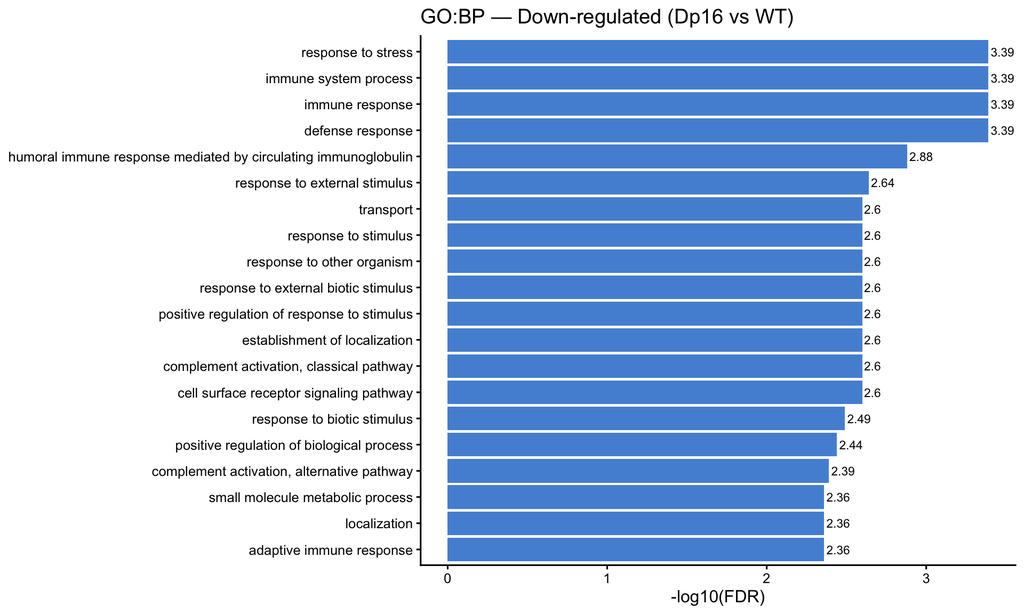

Figura 26. Top 20 procesos biológicos (GO:BP) enriquecidos en genes down-regulated en Dp16 vs WT.

```r
if (!is.null(multi_gp$result)) {
  gost_df <- as.data.frame(multi_gp$result)

  bar_down_plot <- gost_df %>%
    filter(query == "Down-regulated", source == "GO:BP") %>%
    arrange(p_value) %>%
    head(20) %>%
    mutate(log10p = round(-log10(p_value), 2),
           num    = seq_len(n()))

  if (nrow(bar_down_plot) > 0) {
    ggplot(bar_down_plot,
           aes(x = log10p, y = reorder(term_name, log10p))) +
      geom_bar(stat = "identity", fill = "dodgerblue3", alpha = 0.8) +
      geom_text(aes(label = log10p), hjust = -0.1, size = 3) +
      labs(title = "GO:BP — Down-regulated (Dp16 vs WT)",
           x = "-log10(FDR)", y = NULL) +
      theme_classic(base_size = 12) +
      theme(plot.background = element_rect(fill = "white"))
  }
}
```

## 9. Guardar resultados

```r
if (!dir.exists(figdir)) dir.create(figdir, recursive = TRUE)

write.csv(as.data.frame(res_kallisto_shrink),
          file = paste0(outdir, "DESeq2_kallisto_results.csv"))
write.csv(as.data.frame(res_star_shrink),
          file = paste0(outdir, "DESeq2_STAR_results.csv"))
write.csv(sig_kallisto,
          file = paste0(outdir, "DESeq2_kallisto_significant.csv"))
write.csv(sig_star,
          file = paste0(outdir, "DESeq2_STAR_significant.csv"))

if (!is.null(multi_gp$result)) {
  gost_export <- multi_gp$result
  gost_export$parents        <- sapply(gost_export$parents, paste, collapse = ";")
  gost_export$evidence_codes <- sapply(gost_export$evidence_codes, paste, collapse = ";")
  write.csv(gost_export,
            file      = paste0(outdir, "GOterms_gprofiler2_results.csv"),
            row.names = FALSE)
}

save(dds, dds_star,
     vsd_kallisto, vsd_star,
     res_kallisto_shrink, res_star_shrink,
     zscore_mat, melted_norm_counts,
     file = paste0(outdir, "DEG_objects.RData"))

cat("Todos los archivos guardados en:", outdir, "\n")
```

```
## Todos los archivos guardados en: /Users/dubsirubs/Desktop/RNAseq_Equipo4/results_final/
```

## 11. Discusión

### 11.1 Comparación con el artículo de referencia (Dunn et al., 2026)

Una diferencia notable es el número de DEGs detectados: nuestro análisis identificó 400 genes (Kallisto) y 363 (STAR), mientras que Dunn et al. reportan ~1,500 DEGs con el dataset completo. Esta diferencia es atribuible directamente al menor poder estadístico de usar solo 3 réplicas por genotipo en lugar de las 6 disponibles.

### 11.2 Contexto biológico: metabolismo hepático y trisomía 16

El perfil transcriptómico observado en el hígado Dp16 se puede interpretar en el contexto más amplio de la fisiopatología del Síndrome de Down. Tian et al. (2023) demostraron que la trisomía genera resistencia a la insulina, intolerancia a la glucosa y dislipidemia en ambos sexos, con activación de vías del metabolismo lipídico y supresión de la función mitocondrial como patrones compartidos en múltiples tejidos. Nuestros resultados en hígado son compatibles con este patrón sistémico.

### 11.3 Métodos de cuantificación: Kallisto vs STAR

Nuestro análisis muestra que 264 de los DEGs son compartidos entre Kallisto y STAR (~66–73% de overlap), indicando alta concordancia entre pseudoalineamiento y alineamiento directo. Para el análisis de expresión diferencial en tejido hepático con genes bien anotados en GRCm39, ambas estrategias son equivalentes en términos prácticos, en línea con lo reportado por Love et al. (2014).

### 11.4 Represión de la cascada del complemento en Dp16

Un hallazgo particularmente relevante es la represión de genes del complemento y la inmunidad humoral en el hígado Dp16. El hígado es el principal sitio de síntesis de proteínas del complemento, por lo que su represión en Dp16 podría contribuir a la vulnerabilidad inmunológica observada clínicamente en personas con Síndrome de Down. Este patrón es consistente con lo reportado por Dunn et al. (2026).

### 11.5 Limitaciones y perspectivas futuras

El principal factor limitante es el tamaño de muestra (n=3 por genotipo). Adicionalmente, al ser análisis de bulk RNA-seq, no es posible distinguir qué tipos celulares específicos dentro del hígado contribuyen a cada cambio transcriptómico. Como perspectiva futura, incluir las 6 réplicas completas e integrar los datos de scRNA-seq disponibles en el mismo bioproyecto permitiría una caracterización más completa del fenotipo Dp16.

## 12. Outlogs del pipeline

Los archivos de log de cada paso del pipeline están disponibles en el repositorio en `scripts/out_logs/`.

| Paso | Script | Outlogs |
| --- | --- | --- |
| Descarga SRA | `01_download_adapters.sh` | download.out · download.err · download_Dp16.out · download_Dp16.err |
| Trimmomatic | `trimmomatic_final.sh` | trimm_final_1611.out · trimm_final_1611.err |
| Kallisto (×6 muestras) | `03_kallisto.sh` | _0 · _1 · _2 · _3 · _4 · _5 |
| STAR index | `04_STAR_index.sh` | STAR_index.out · STAR_index.err |
| STAR align (×6 muestras) | `05_STAR_align.sh` | _0 · _1 · _2 · _3 · _4 · _5 |

## 13. Referencias

1. Dunn, A. et al., 2026. Altered hepatic metabolism in Down syndrome. *Cell Reports*. DOI: 10.1016/j.celrep.2025.116835
2. Love, M.I., Huber, W., & Anders, S., 2014. Moderated estimation of fold change and dispersion for RNA-seq data with DESeq2. *Genome Biology*, 15, 550. DOI: 10.1186/s13059-014-0550-8
3. Tian, Y. et al., 2023. Gene dosage imbalance disrupts systemic metabolism in the Dp16 Down syndrome mouse model. DOI: 10.64898/2026.01.13.699318
4. Bray, N.L., Pimentel, H., Melsted, P., & Pachter, L., 2016. Near-optimal probabilistic RNA-seq quantification. *Nature Biotechnology*, 34, 525–527. DOI: 10.1038/nbt.3519

*Documento generado con R Markdown.*  
*Análisis realizado en el cluster `ken.lavis.unam.mx`*  
*Ruta del proyecto: `/mnt/data/bioinfo-estadistica-2/RNAseq_2026/equipos/Equipo4/`*